# Urban Sustainability & Renewable Energy Potential in the Baltic States

## course: Resposible Data Analytics course

Name: **Milad Torabi**  
Student ID: **6354688**

Name: **Jennifer Hu**  
student ID: **5406625**

# Project Overview:

#### Context:

- Focus on **three Baltic capitals: Vilnius, Tallinn, and Riga**
- Analysis based on **5 years of meteorological data from NASA POWER**(from 2018 to 2022)
- Data Source: https://power.larc.nasa.gov/data-access-viewer/

#### Objective:

- Investigate **how key weather parameters affect renewable energy potential and urban sustainability**
- Provide actionable insights for **urban planning and energy strategies**

# Research Questions and Sub-Questions:

#### Primary Research Question:

- How do variations in meteorological parameters influence renewable energy potential and urban sustainability in Vilnius, Tallinn, and Riga?

#### Sub-Questions:

##### 1.Descriptive Analytics:

- What are the **historical trends and seasonal patterns** of **key weather variables?**

##### 2.Diagnostic Analytics:

- How do solar, temperature, moisture, and wind **variables correlate and interact**?

##### 3.Predictive Analytics:

- Can we **predict solar radiation** based on other meteorological data that **impact renewable energy generation and potential**?

##### 4.Prescriptive Analytics:

- What **general strategies** can be used to **optimize renewable energy deployment**, and what specific **actions** can be taken **based on predicted solar radiation**?

# Analysis Pipeline(Helicopter View)

### 1.Data Collection, Understanding, and Preprocessing:

- Load the CSV files and Check the structure.
- Inspect the datasets for missing values, duplicates, and inconsistencies.
- Verify consistency across the three datasets.
- Merge datasets to align variables for Vilnius, Riga, and Tallinn.
- Exploration of the Dataset and Relevant Variables
- Domain-based categorization and description of the available variables.
- Filter out unnecessary variables, keeping only the key variables of interest.
- Potential Risks and Bias Identification

#### 2.Descriptive Analytics

#### 3.Diagnostic Analytics

#### 4.Predictive Analytics

#### 5.Prescriptive Analytics

### To run this notebook, make sure you’ve installed the required libraries, If you haven’t already, install them with:

```python
# pip install gdown plotly calmap shap joblib
```

```python
# Ensure Plotly is Embedded in HTML
import plotly.io as pio
pio.renderers.default = 'notebook_connected'  # best for HTML export
```

```python
# Core Libraries
import pandas as pd
import numpy as np
import calendar
import warnings  # handle/suppress warnings

# Visualization
import matplotlib.pyplot as plt
import seaborn as sns
import plotly.graph_objects as go
from plotly.subplots import make_subplots
import plotly.express as px
import calmap

# Time Series Analysis
from statsmodels.tsa.seasonal import seasonal_decompose

# Statistical Analysis
from scipy.stats import gaussian_kde

# Model Evaluation
from sklearn.metrics import mean_absolute_error, mean_squared_error, r2_score , explained_variance_score

# Model Building
from sklearn.model_selection import TimeSeriesSplit  # time-series-aware CV
from sklearn.ensemble import RandomForestRegressor, GradientBoostingRegressor, StackingRegressor
from sklearn.svm import SVR
from sklearn.neural_network import MLPRegressor
from sklearn.linear_model import RidgeCV
from sklearn.pipeline import Pipeline  # build model pipelines
from sklearn.preprocessing import StandardScaler  # feature normalization
from sklearn.base import clone  # deep copy of models

# Model saving
import joblib

# Additional Tools
import gdown  # Download files from Google Drive
from tqdm.auto import tqdm  # progress bar
from sklearn.exceptions import ConvergenceWarning  # specific warning for convergence issues
import shap  # model explainability
```

```python
# Extract file IDs from the links
Riga_id = "1pNvOTLYSKb7G3fSw3xx3pi7B2_AoQg_H"
Talinn_id = "1xPeyM2KBVQXXyLvDTCSDiE39Ag8-1jut"
Vilnius_id = "1aqkwsQvBPRVQluvhYgb9QcMOxrmqn8ed"

# Download the files correctly
data_Riga = gdown.download(f"https://drive.google.com/uc?id={Riga_id}", "data_Riga.ext", quiet=False)
data_Talinn = gdown.download(f"https://drive.google.com/uc?id={Talinn_id}", "data_Talinn.ext", quiet=False)
data_Vilnius = gdown.download(f"https://drive.google.com/uc?id={Vilnius_id}", "data_Vilnius.ext", quiet=False)

print("Files downloaded successfully!")
```

```
Downloading...
From: https://drive.google.com/uc?id=1pNvOTLYSKb7G3fSw3xx3pi7B2_AoQg_H
To: C:\Users\LENOVO\Desktop\SEN163B_2024_2025_Group08_Final_submission\data_Riga.ext
Downloading...
From: https://drive.google.com/uc?id=1xPeyM2KBVQXXyLvDTCSDiE39Ag8-1jut
To: C:\Users\LENOVO\Desktop\SEN163B_2024_2025_Group08_Final_submission\data_Talinn.ext
Downloading...
From: https://drive.google.com/uc?id=1aqkwsQvBPRVQluvhYgb9QcMOxrmqn8ed
To: C:\Users\LENOVO\Desktop\SEN163B_2024_2025_Group08_Final_submission\data_Vilnius.ext
```

```
Files downloaded successfully!
```

```python
# To inspect only the first 200 lines of the Riga data set
with open(data_Riga, 'r') as file:
    for i, line in enumerate(file):
        if i >= 50:
            break
        print(line.strip())
```

```
-BEGIN HEADER-
NASA/POWER Source Native Resolution Daily Data
Dates (month/day/year): 01/01/2018 through 12/31/2022 in LST
Location: latitude  56.9474   longitude 24.1069
elevation from MERRA-2: Average for 0.5 x 0.625 degree lat/lon region = 42.62 meters
The value for missing source data that cannot be computed or is outside of the sources availability range: -999
parameter(s):
ALLSKY_SFC_SW_DWN       CERES SYN1deg All Sky Surface Shortwave Downward Irradiance (kW-hr/m^2/day)
CLRSKY_SFC_SW_DWN       CERES SYN1deg Clear Sky Surface Shortwave Downward Irradiance (kW-hr/m^2/day)
ALLSKY_KT               CERES SYN1deg All Sky Insolation Clearness Index (dimensionless)
ALLSKY_SFC_LW_DWN       CERES SYN1deg All Sky Surface Longwave Downward Irradiance (kW-hr/m^2/day)
ALLSKY_SFC_UVA          CERES SYN1deg All Sky Surface UVA Irradiance (kW-hr/m^2/day)
ALLSKY_SFC_UV_INDEX     CERES SYN1deg All Sky Surface UV Index (W m-2 x 40)
T2M                     MERRA-2 Temperature at 2 Meters (C)
T2MDEW                  MERRA-2 Dew/Frost Point at 2 Meters (C)
T2MWET                  MERRA-2 Wet Bulb Temperature at 2 Meters (C)
TS                      MERRA-2 Earth Skin Temperature (C)
QV2M                    MERRA-2 Specific Humidity at 2 Meters (g/kg)
RH2M                    MERRA-2 Relative Humidity at 2 Meters (%)
PRECTOTCORR             MERRA-2 Precipitation Corrected (mm/day)
PS                      MERRA-2 Surface Pressure (kPa)
WS10M                   MERRA-2 Wind Speed at 10 Meters (m/s)
WS10M_MAX               MERRA-2 Wind Speed at 10 Meters Maximum (m/s)
WS10M_MIN               MERRA-2 Wind Speed at 10 Meters Minimum (m/s)
WS10M_RANGE             MERRA-2 Wind Speed at 10 Meters Range (m/s)
WD10M                   MERRA-2 Wind Direction at 10 Meters (Degrees)
-END HEADER-
YEAR,MO,DY,ALLSKY_SFC_SW_DWN,CLRSKY_SFC_SW_DWN,ALLSKY_KT,ALLSKY_SFC_LW_DWN,ALLSKY_SFC_UVA,ALLSKY_SFC_UV_INDEX,T2M,T2MDEW,T2MWET,TS,QV2M,RH2M,PRECTOTCORR,PS,WS10M,WS10M_MAX,WS10M_MIN,WS10M_RANGE,WD10M
2018,1,1,0.08,0.47,0.07,7.1,0.01,0.01,1.28,0.84,1.06,1.12,4.11,97.05,8.28,99.12,6.85,8.48,5.68,2.8,188.8
2018,1,2,0.48,0.62,0.42,6.6,0.02,0.02,1.19,0.71,0.95,1.15,4.03,96.67,0.35,99.85,7.02,8.36,5.44,2.92,201.1
2018,1,3,0.24,0.6,0.21,7.2,0.01,0.01,-0.09,-0.67,-0.38,0.15,3.64,96.05,0.29,99.61,5.6,6.38,4.94,1.44,158.9
2018,1,4,0.13,0.51,0.11,7.35,0.01,0.01,1.05,0.41,0.73,0.88,3.97,95.42,1.41,98.87,7.53,8.28,5.61,2.67,144.6
2018,1,5,0.2,0.57,0.17,7.44,0.01,0.01,1.63,1.19,1.42,1.42,4.2,96.81,4.82,98.82,7.72,8.58,6.54,2.04,169.2
2018,1,6,0.28,0.67,0.23,7.48,0.02,0.01,1.57,1.16,1.36,1.27,4.16,96.96,1.05,99.61,5.37,6.38,4.47,1.91,249.7
2018,1,7,0.71,0.77,0.58,5.89,0.03,0.02,-1.31,-3.47,-2.39,-1.36,2.9,85.88,0.2,101.45,7.09,10.66,5.67,4.99,277.3
2018,1,8,0.6,0.76,0.48,6.36,0.03,0.02,-0.38,-2.78,-1.58,-0.8,3.03,84.2,0.19,102.19,7.56,10.53,4.61,5.92,289.6
2018,1,9,0.15,0.76,0.12,7.28,0.01,0.01,0.57,0.19,0.38,0.55,3.77,97.31,0.72,102.55,5.12,6.33,2.75,3.58,273.0
2018,1,10,0.35,0.83,0.27,6.94,0.02,0.02,-3.32,-4.33,-3.82,-3.06,2.7,94.78,0.13,102.12,2.54,3.46,1.05,2.41,162.5
2018,1,11,0.2,0.82,0.15,6.58,0.01,0.01,-5.73,-6.78,-6.26,-4.93,2.21,95.99,0.1,102.16,3.49,4.91,2.5,2.41,95.0
2018,1,12,0.54,0.83,0.4,5.93,0.03,0.02,-5.27,-6.82,-6.04,-4.81,2.18,91.76,0.06,103.32,4.25,4.86,3.39,1.47,113.5
2018,1,13,0.56,0.87,0.41,5.14,0.03,0.02,-8.23,-9.18,-8.7,-7.68,1.77,96.22,0.0,103.85,3.2,4.09,2.2,1.89,152.2
2018,1,14,0.26,0.9,0.18,6.22,0.02,0.02,-9.1,-10.14,-9.62,-7.76,1.63,96.31,0.12,103.47,3.33,4.94,2.23,2.71,148.9
2018,1,15,0.39,0.91,0.27,5.86,0.02,0.02,-9.31,-10.9,-10.1,-7.87,1.55,92.53,0.08,102.46,6.48,8.59,5.07,3.52,167.3
2018,1,16,0.93,0.95,0.63,4.44,0.04,0.03,-9.42,-11.03,-10.23,-7.87,1.56,92.09,0.06,100.42,10.77,12.15,8.95,3.2,150.5
2018,1,17,0.37,0.87,0.25,5.94,0.02,0.02,-8.38,-9.63,-9.01,-6.94,1.8,94.61,2.14,98.89,6.94,10.22,2.42,7.8,126.6
2018,1,18,0.19,0.83,0.13,6.68,0.01,0.01,-5.14,-5.78,-5.46,-4.56,2.49,97.63,3.11,99.08,3.3,5.45,1.44,4.01,188.7
2018,1,19,0.37,0.94,0.24,6.5,0.02,0.02,-4.53,-5.29,-4.91,-4.41,2.56,97.13,0.02,99.58,3.99,5.15,2.88,2.27,102.2
2018,1,20,0.23,0.98,0.14,6.63,0.02,0.02,-4.85,-6.09,-5.47,-5.5,2.38,94.19,0.24,100.23,1.66,2.74,0.84,1.9,73.3
2018,1,21,0.46,1.03,0.28,6.44,0.03,0.02,-5.58,-6.37,-5.98,-6.35,2.32,96.94,0.38,100.76,2.0,3.63,0.17,3.46,332.1
2018,1,22,0.27,1.08,0.16,6.42,0.02,0.02,-6.49,-7.1,-6.79,-5.92,2.18,98.86,1.3,101.17,5.9,7.74,3.29,4.45,225.8
```

```python
# The specific information about three Cities:
#  Riga Location: latitude  56.9474   longitude 24.1069
#  Vilnius Location: latitude  54.691   longitude 25.2823
#  Tallin Location: latitude  59.4324   longitude 24.7441

# Since the first 27 rows of the data has differnet structure, we seprate the datasets into 2 parts. these 27 rows are
# the Header of the data and the following table part includs the features of each city which we want to analyzie

data_Riga = pd.read_csv( data_Riga, skiprows=27)
data_Vilnius = pd.read_csv( data_Vilnius, skiprows=27)
data_Talinn = pd.read_csv( data_Talinn, skiprows=27)
```

```python
# check the consistency of the datasets before merging them
print(data_Vilnius.columns == data_Riga.columns)
print(data_Riga.columns == data_Talinn.columns)
```

```
[ True  True  True  True  True  True  True  True  True  True  True  True
  True  True  True  True  True  True  True  True  True  True]
[ True  True  True  True  True  True  True  True  True  True  True  True
  True  True  True  True  True  True  True  True  True  True]
```

```python
# since columns(features) of the 3 datasets are the same, we can concatenate them one after the
# other to have a single data set, but we need to only add a column representing the city of them.
data_Vilnius['City']='Vilnius'
data_Talinn['City']='Tallinn'
data_Riga['City']='Riga'

# Correct ignore_index usage
dataset = pd.concat([data_Vilnius, data_Talinn, data_Riga], ignore_index=True)

# Rename columns to match expected names
dataset = dataset.rename(columns={'YEAR': 'year', 'MO': 'month', 'DY': 'day'})

# Convert to datetime
dataset['DATE'] = pd.to_datetime(dataset[['year', 'month', 'day']])

# Setting 'DATE' as the index
dataset.set_index('DATE', inplace=True)

# Dropping redundant columns after conversion
dataset.drop(columns=['year', 'month', 'day'], inplace=True)

# Display dataset # Now dataset is indexed by 'DAY'
dataset
```

| DATE | ALLSKY_SFC_SW_DWN | CLRSKY_SFC_SW_DWN | ALLSKY_KT | ALLSKY_SFC_LW_DWN | ALLSKY_SFC_UVA | ALLSKY_SFC_UV_INDEX | T2M | T2MDEW | T2MWET | TS | QV2M | RH2M | PRECTOTCORR | PS | WS10M | WS10M_MAX | WS10M_MIN | WS10M_RANGE | WD10M | City |
| --- | --- | --- | --- | --- | --- | --- | --- | --- | --- | --- | --- | --- | --- | --- | --- | --- | --- | --- | --- | --- |
| 2018-01-01 | 0.14 | 0.66 | 0.10 | 7.15 | 0.01 | 0.01 | 0.88 | 0.63 | 0.76 | 0.56 | 4.07 | 98.22 | 4.49 | 98.35 | 4.74 | 6.80 | 3.03 | 3.77 | 196.0 | Vilnius |
| 2018-01-02 | 0.28 | 0.79 | 0.20 | 7.00 | 0.02 | 0.01 | 0.03 | -0.22 | -0.10 | -0.06 | 3.79 | 98.21 | 0.88 | 98.88 | 2.76 | 3.30 | 2.02 | 1.28 | 190.2 | Vilnius |
| 2018-01-03 | 0.24 | 0.77 | 0.17 | 7.09 | 0.01 | 0.01 | 0.10 | -0.23 | -0.06 | -0.19 | 3.81 | 97.80 | 0.64 | 98.38 | 3.30 | 5.09 | 1.95 | 3.14 | 163.5 | Vilnius |
| 2018-01-04 | 0.21 | 0.71 | 0.14 | 7.30 | 0.01 | 0.01 | 1.03 | 0.72 | 0.88 | 0.71 | 4.11 | 97.68 | 0.59 | 97.79 | 5.52 | 6.01 | 5.11 | 0.90 | 172.5 | Vilnius |
| 2018-01-05 | 0.30 | 0.76 | 0.20 | 7.41 | 0.02 | 0.01 | 0.82 | 0.52 | 0.67 | 0.62 | 4.04 | 97.75 | 2.33 | 97.97 | 5.64 | 7.00 | 4.66 | 2.34 | 176.7 | Vilnius |
| ... | ... | ... | ... | ... | ... | ... | ... | ... | ... | ... | ... | ... | ... | ... | ... | ... | ... | ... | ... | ... |
| 2022-12-27 | 0.29 | 0.59 | 0.27 | 6.64 | 0.02 | 0.01 | 0.25 | -0.41 | -0.08 | -0.04 | 3.73 | 95.95 | 2.15 | 100.01 | 7.00 | 7.95 | 5.72 | 2.23 | 233.5 | Riga |
| 2022-12-28 | 0.29 | 0.54 | 0.27 | 6.80 | 0.02 | 0.01 | 0.43 | -0.12 | 0.15 | 0.36 | 3.75 | 96.00 | 2.55 | 100.53 | 5.90 | 7.35 | 4.79 | 2.56 | 228.3 | Riga |
| 2022-12-29 | 0.22 | 0.50 | 0.20 | 6.93 | 0.01 | 0.01 | 0.28 | -0.13 | 0.08 | 0.29 | 3.78 | 97.20 | 2.61 | 99.98 | 5.84 | 7.35 | 4.81 | 2.54 | 177.4 | Riga |
| 2022-12-30 | 0.15 | 0.50 | 0.14 | 7.01 | 0.01 | 0.01 | 1.76 | 1.50 | 1.62 | 1.05 | 4.25 | 98.33 | 3.55 | 100.01 | 6.28 | 7.06 | 5.53 | 1.53 | 229.2 | Riga |
| 2022-12-31 | 0.17 | 0.51 | 0.15 | 6.61 | 0.01 | 0.01 | 1.39 | 1.10 | 1.24 | 1.05 | 4.13 | 98.02 | 2.96 | 100.06 | 7.53 | 9.67 | 6.08 | 3.59 | 195.2 | Riga |

5478 rows × 20 columns

```python
# Check for any missing value or feature
print(f'missing value or feature per column: \n{dataset.isna().sum()}\n')

# Display rows with missing values
print(f'rows with missing values: {dataset[dataset.isnull().any(axis=1)]}')

# Count duplicate rows
print(f'Duplicate rows: {dataset.duplicated().sum()}')

# check the data type of each column
print(f'Data types: {dataset.dtypes}')
```

```
missing value or feature per column:
ALLSKY_SFC_SW_DWN      0
CLRSKY_SFC_SW_DWN      0
ALLSKY_KT              0
ALLSKY_SFC_LW_DWN      0
ALLSKY_SFC_UVA         0
ALLSKY_SFC_UV_INDEX    0
T2M                    0
T2MDEW                 0
T2MWET                 0
TS                     0
QV2M                   0
RH2M                   0
PRECTOTCORR            0
PS                     0
WS10M                  0
WS10M_MAX              0
WS10M_MIN              0
WS10M_RANGE            0
WD10M                  0
City                   0
dtype: int64

rows with missing values: Empty DataFrame
Columns: [ALLSKY_SFC_SW_DWN, CLRSKY_SFC_SW_DWN, ALLSKY_KT, ALLSKY_SFC_LW_DWN, ALLSKY_SFC_UVA, ALLSKY_SFC_UV_INDEX, T2M, T2MDEW, T2MWET, TS, QV2M, RH2M, PRECTOTCORR, PS, WS10M, WS10M_MAX, WS10M_MIN, WS10M_RANGE, WD10M, City]
Index: []
Duplicate rows: 0
Data types: ALLSKY_SFC_SW_DWN      float64
CLRSKY_SFC_SW_DWN      float64
ALLSKY_KT              float64
ALLSKY_SFC_LW_DWN      float64
ALLSKY_SFC_UVA         float64
ALLSKY_SFC_UV_INDEX    float64
T2M                    float64
T2MDEW                 float64
T2MWET                 float64
TS                     float64
QV2M                   float64
RH2M                   float64
PRECTOTCORR            float64
PS                     float64
WS10M                  float64
WS10M_MAX              float64
WS10M_MIN              float64
WS10M_RANGE            float64
WD10M                  float64
City                    object
dtype: object
```

#### Data Preprocessing Report

- The dataset contains **no missing values** in either rows or columns.
- **No duplicate entries** are present, ensuring data integrity.
- All columns are of **numeric type (float64)**, except for one column ("City") which is of type object.
- The "City" column remains as a categorical variable in text format for now, as it is needed for analysis.
- **Encoding of the "City" column** (e.g., one-hot or ordinal encoding) will be applied later when performing machine learning tasks.
- **The dataset was merged** to align **variables for Vilnius, Riga, and Tallinn**, ensuring consistency across cities.

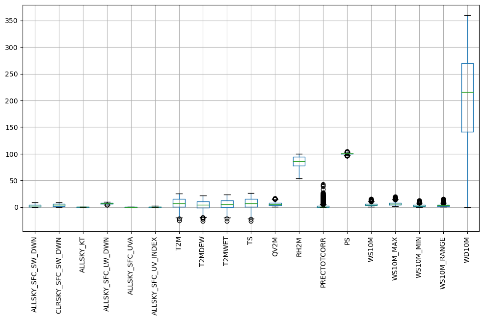

```python
# Check for outliers using boxplots
plt.figure(figsize=(12, 6))
dataset.boxplot(rot=90)

plt.show()
```

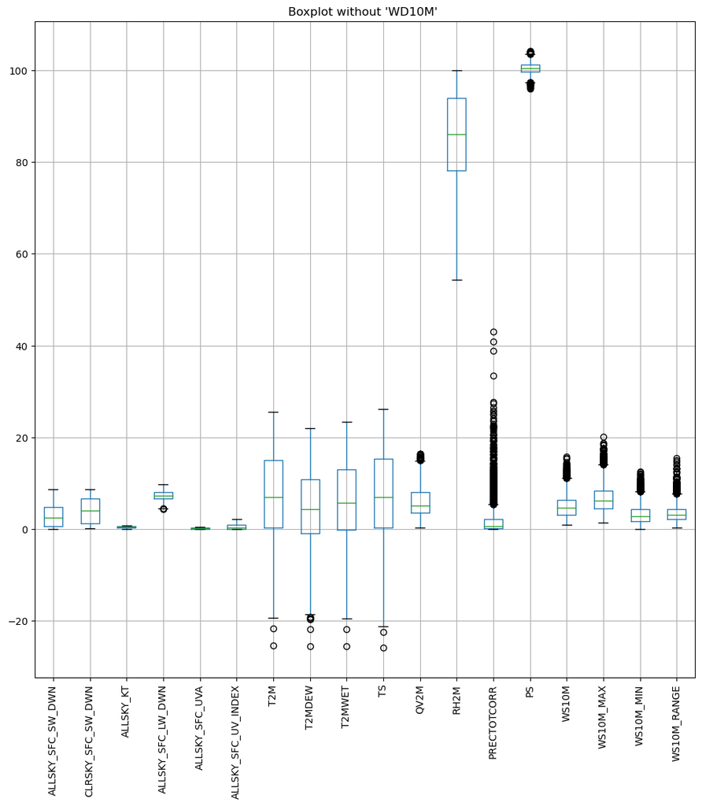

```python
# since the'WD10M' column distorts the boxplot and also does not have any outliers,
# we need to exclude it to make the visualization clearer:
plt.figure(figsize=(12,12))
dataset.drop(columns=['WD10M']).boxplot(rot=90)
plt.title("Boxplot without 'WD10M' ")
plt.show()
```

```python
#  in order to better understand the columns that have outliers and to Confirm Outliers Numerically:

# List of columns to check for outliers
list_columns_with_outliers = ['ALLSKY_SFC_LW_DWN', 'T2M', 'T2MDEW', 'T2MWET', 'TS',
                              'QV2M', 'PRECTOTCORR', 'PS', 'WS10M', 'WS10M_MAX',
                              'WS10M_MIN', 'WS10M_RANGE']

# Function to detect and print outliers
def Confirm_Outliers(column):
    Q1 = dataset[column].quantile(0.25)
    Q3 = dataset[column].quantile(0.75)
    IQR = Q3 - Q1

    lower_bound = Q1 - 1.5 * IQR
    upper_bound = Q3 + 1.5 * IQR

    # Filtering outliers
    outliers = dataset[(dataset[column] < lower_bound) | (dataset[column] > upper_bound)]

    return outliers  # Return the outliers

# Loop through columns and print outliers
for column_name in list_columns_with_outliers:
    outliers_df = Confirm_Outliers(column_name)  # Get outliers
    print(f"\nOutliers for column: {column_name}")
    print(outliers_df[f'{column_name}'])
```

```
Outliers for column: ALLSKY_SFC_LW_DWN
DATE
2018-01-16    4.41
2021-01-16    4.44
2018-01-16    4.44
Name: ALLSKY_SFC_LW_DWN, dtype: float64

Outliers for column: T2M
DATE
2021-01-16   -21.69
2021-01-17   -25.42
Name: T2M, dtype: float64

Outliers for column: T2MDEW
DATE
2021-01-16   -21.83
2021-01-17   -25.48
2021-01-18   -19.62
2021-01-19   -19.46
2021-02-07   -19.57
2021-02-08   -19.21
2021-12-08   -19.18
Name: T2MDEW, dtype: float64

Outliers for column: T2MWET
DATE
2021-01-16   -21.76
2021-01-17   -25.45
Name: T2MWET, dtype: float64

Outliers for column: TS
DATE
2021-01-16   -22.38
2021-01-17   -25.81
Name: TS, dtype: float64

Outliers for column: QV2M
DATE
2018-07-28    15.43
2018-07-29    16.24
```

[output cut: 136 more lines]

```

Outliers for column: WS10M_RANGE
DATE
2018-04-06     7.75
2020-03-13     7.85
2021-05-02     7.77
2021-11-30     8.29
2018-01-08    10.33
              ...
2022-07-12     8.45
2022-10-03     8.65
2022-12-11     7.97
2022-12-12     9.18
2022-12-18     8.36
Name: WS10M_RANGE, Length: 192, dtype: float64
```

### Outlier Assessment

- The detected outliers are **genuine data points** rather than errors or noise.
- These outliers will be **retained** for now and transformed if necessary in later analysis.
- For machine learning models, techniques like **StandardScaler or RobustScaler** (from sklearn.preprocessing) will be used to minimize the impact of outliers while preserving data integrity.

```python
# Summary Statistics for each city
summary_stats = dataset.groupby('City').describe()
summary_stats
```

| City | ALLSKY_SFC_SW_DWN count | ALLSKY_SFC_SW_DWN mean | ALLSKY_SFC_SW_DWN std | ALLSKY_SFC_SW_DWN min | ALLSKY_SFC_SW_DWN 25% | ALLSKY_SFC_SW_DWN 50% | ALLSKY_SFC_SW_DWN 75% | ALLSKY_SFC_SW_DWN max | CLRSKY_SFC_SW_DWN count | CLRSKY_SFC_SW_DWN mean | ... | WS10M_RANGE 75% | WS10M_RANGE max | WD10M count | WD10M mean | WD10M std | WD10M min | WD10M 25% | WD10M 50% | WD10M 75% | WD10M max |
| --- | --- | --- | --- | --- | --- | --- | --- | --- | --- | --- | --- | --- | --- | --- | --- | --- | --- | --- | --- | --- | --- |
| Riga | 1826.0 | 2.913149 | 2.358842 | 0.08 | 0.61 | 2.475 | 4.8425 | 8.62 | 1826.0 | 4.071791 | ... | 4.3775 | 14.66 | 1826.0 | 201.764732 | 89.175901 | 0.7 | 146.325 | 212.65 | 266.3 | 359.1 |
| Tallinn | 1826.0 | 2.809485 | 2.421815 | 0.05 | 0.44 | 2.235 | 4.8175 | 8.23 | 1826.0 | 3.840641 | ... | 5.3175 | 15.56 | 1826.0 | 200.536145 | 90.755343 | 0.4 | 141.175 | 217.35 | 265.4 | 359.9 |
| Vilnius | 1826.0 | 2.961506 | 2.278075 | 0.11 | 0.73 | 2.580 | 4.7500 | 8.45 | 1826.0 | 4.179628 | ... | 3.4500 | 8.29 | 1826.0 | 201.145071 | 93.882391 | 0.1 | 135.400 | 217.75 | 275.1 | 359.7 |

3 rows × 152 columns

Since our dataset contains meteorological and solar radiation data, the risks and biases may stem from data quality issues, geographic limitations, and external influences. Here’s how we can systematically analyze and mitigate biases.

## Potential Risks and Bias Identification:

- A. Data Quality Issues: we can check for Missing Values & Outliers for all these three datasets.(Already Done)
- B. Bias in Time Period  
  The dataset covers only 5 years (2018-2022). Any climate trends beyond this period are not captured, leading to a short-term bias.  
  Solution: If needed, integrate older datasets for a longer-term trend analysis.(but here we focus on 5 years only)  
  Short-Term Analysis Bias: Trends might not reflect long-term climate behavior, leading to incorrect predictions.
- C. Geographic Bias  
  our dataset only covers Vilnius, Tallinn, and Riga.  
  Any insights may not generalize to other regions with different climatic conditions.  
  Solution: we can Compare with data from cities in similar latitudes but different climates.  
  Geographic Limitation: Applying insights from three cities to other locations can be misleading.
- D. External Influences (Climate Change, Urbanization)  
  Temperature changes may be affected by urban heat islands.  
  Changes in precipitation and wind speed could be influenced by climate change trends rather than local factors.  
  Solution: we can Compare data with global climate change trends.

## Exploration of the Dataset and Relevant Variables

The NASA POWER dataset has a variety of meteorological variables and solar radiation measurements that are relevant to urban sustainability and renewable energy.

### Understanding the Parameters:

- All parameters based on NASA data:

  ```
  ALLSKY_SFC_SW_DWN :   All Sky Surface Shortwave Downward Irradiance (kW-hr/m^2/day)

  CLRSKY_SFC_SW_DWN :   Clear Sky Surface Shortwave Downward Irradiance (kW-hr/m^2/day)

  ALLSKY_KT :           All Sky Insolation Clearness Index (dimensionless)

  ALLSKY_SFC_LW_DWN :   All Sky Surface Longwave Downward Irradiance (kW-hr/m^2/day)

  ALLSKY_SFC_UVA :      All Sky Surface UVA Irradiance (kW-hr/m^2/day)

  ALLSKY_SFC_UV_INDEX : All Sky Surface UV Index (W m-2 x 40)

  T2M :                 Temperature at 2 Meters (C)

  T2MDEW :              Dew/Frost Point at 2 Meters (C)

  T2MWET :              Wet Bulb Temperature at 2 Meters (C)

  TS :                  Earth Skin Temperature (C)

  QV2M :                Specific Humidity at 2 Meters (g/kg)

  RH2M :                Relative Humidity at 2 Meters (%)

  PRECTOTCORR :         Precipitation Corrected (mm/day)

  PS :                  Surface Pressure (kPa)

  WS10M :               Wind Speed at 10 Meters (m/s)

  WS10M_MAX :           Wind Speed at 10 Meters Maximum (m/s)

  WS10M_MIN :           Wind Speed at 10 Meters Minimum (m/s)

  WS10M_RANGE :         Wind Speed at 10 Meters Range (m/s)

  WD10M :               Wind Direction at 10 Meters (Degrees)
  ```

### Meteorological Variables Description Table for Understanding the Parameters (for Non-Technical Users)

| Variable Name | Category | Description |
| --- | --- | --- |
| ALLSKY_SFC_SW_DWN | Solar Radiation & UV (CERES SYN1deg) | Total shortwave (SW) radiation received at the surface under all sky conditions (incl. clouds). |
| CLRSKY_SFC_SW_DWN | Solar Radiation & UV (CERES SYN1deg) | Shortwave radiation received at the surface assuming clear skies (no clouds). |
| ALLSKY_KT | Solar Radiation & UV (CERES SYN1deg) | Clearness index; fraction of solar radiation transmitted through the atmosphere. |
| ALLSKY_SFC_LW_DWN | Solar Radiation & UV (CERES SYN1deg) | Longwave (LW) radiation received at the surface under all sky conditions. |
| ALLSKY_SFC_UVA | Solar Radiation & UV (CERES SYN1deg) | Ultraviolet-A (UVA) radiation received at the surface. |
| ALLSKY_SFC_UV_INDEX | Solar Radiation & UV (CERES SYN1deg) | A measure of UV intensity, relevant for skin exposure risks. |
| T2M | Temperature & Humidity (MERRA-2) | Air temperature at 2 meters above the ground. |
| T2MDEW | Temperature & Humidity (MERRA-2) | Dew point temperature, indicating saturation point of air moisture. |
| T2MWET | Temperature & Humidity (MERRA-2) | Wet bulb temperature, relevant for heat stress analysis. |
| TS | Temperature & Humidity (MERRA-2) | Skin temperature of the Earth’s surface (land/sea surface). |
| QV2M | Temperature & Humidity (MERRA-2) | Specific humidity; amount of water vapor in the air. |
| RH2M | Temperature & Humidity (MERRA-2) | Relative humidity; moisture content relative to the air's capacity. |
| PRECTOTCORR | Precipitation & Pressure (MERRA-2) | Daily corrected total precipitation. |
| PS | Precipitation & Pressure (MERRA-2) | Surface pressure, useful in weather pattern analysis. |
| WS10M | Wind (MERRA-2) | Wind speed at 10 meters above the ground. |
| WS10M_MAX | Wind (MERRA-2) | Maximum wind speed recorded at 10 meters. |
| WS10M_MIN | Wind (MERRA-2) | Minimum wind speed recorded at 10 meters. |
| WS10M_RANGE | Wind (MERRA-2) | Difference between maximum and minimum wind speed. |
| WD10M | Wind (MERRA-2) | Wind direction at 10 meters (in degrees). |

These variables collectively enable an in-depth exploration across descriptive, diagnostic, predictive, and prescriptive analyses related to urban energy and climate challenges.

# domain-based categorization and description of the available variables:

To determine the most prominent features among the 19 provided in the NASA dataset when it comes to key weather variables, especially in the context of urban energy and climate challenges, we need to identify which variables are essential for describing weather conditions and have significant impacts on applications like energy demand, climate analysis, and urban planning. The dataset includes variables from CERES SYN1deg (solar radiation and UV-related) and MERRA-2 (temperature, humidity, precipitation, pressure, and wind). Let’s evaluate these based on their relevance and common usage in meteorology and related fields.

### Core Weather Variables

Key weather variables are typically those that define the state of the atmosphere and are widely used in weather forecasting, climate studies, and practical applications. These often include temperature, humidity, precipitation, wind, pressure, and solar radiation. Given our project overview and the dataset’s focus on urban energy and climate challenges, we’ll prioritize variables that directly influence energy use (e.g., heating, cooling, solar power) and climate phenomena (e.g., precipitation patterns, heat stress).

#### 1. Temperature

Temperature is a fundamental weather variable, driving energy demands for heating and cooling in urban settings. Among the temperature-related variables:

- **T2M**: Air temperature at 2 meters above the ground is the standard measurement reported in weather forecasts and used in energy models.
- **TS**: Surface skin temperature is more relevant for land-surface interactions but less directly tied to human experience or building energy needs.
- **T2MDEW** (dew point) and **T2MWET** (wet bulb temperature) provide additional moisture-related insights but are supplementary to air temperature for general weather description.

**T2M** stands out as the most prominent due to its universal application and direct relevance.

#### 2. Humidity

Humidity affects human comfort, cooling loads, and atmospheric processes. The options are:

- **RH2M**: Relative humidity at 2 meters is commonly reported in weather forecasts and relates directly to perceived moisture, making it intuitive and widely applicable.
- **QV2M**: Specific humidity is a precise scientific measure but less commonly used in everyday contexts.
- **T2MDEW** and **T2MWET** overlap with humidity but are more specialized (e.g., T2MWET for heat stress).

**RH2M** is the most prominent humidity variable due to its standard use and relevance to urban energy (e.g., air conditioning efficiency).

#### 3. Precipitation

Precipitation is critical for water resource management, urban drainage, and climate impacts. The dataset offers:

- **PRECTOTCORR**: Daily corrected total precipitation, which is a direct and comprehensive measure of rainfall or snowfall.

**PRECTOTCORR** is clearly prominent as the sole precipitation variable and essential for climate and urban planning.

#### 4. Wind

Wind influences ventilation, pollutant dispersion, and renewable energy potential. The wind variables include:

- **WS10M**: Wind speed at 10 meters is the standard measure for weather reporting and energy applications (e.g., wind power).
- **WD10M**: Wind direction at 10 meters complements wind speed by indicating airflow patterns, crucial for urban microclimates and air quality.
- **WS10M_MAX**, **WS10M_MIN**, and **WS10M_RANGE** provide additional detail but are derived from WS10M and less fundamental.

**WS10M** and **WD10M** are the most prominent, offering a complete picture of wind behavior with broad applicability.

#### 5. Pressure

Surface pressure helps analyze weather systems (e.g., highs and lows). The dataset includes:

- **PS**: Surface pressure, a standard meteorological variable used in forecasting and understanding atmospheric dynamics.

**PS** is prominent as a core variable, though its direct impact on urban energy may be less immediate than others.

#### 6. Solar Radiation and UV-Related Variables:

Solar radiation is vital for energy applications (e.g., solar power, building heat gain) and climate energy balances. The options are:

- **ALLSKY_SFC_SW_DWN**: Total shortwave radiation at the surface under all sky conditions directly measures solar energy input, affecting temperature and energy demand.
- **CLRSKY_SFC_SW_DWN**: Clear-sky shortwave radiation is a theoretical baseline, less practical for real-world conditions.
- **ALLSKY_KT**: Clearness index indicates cloudiness but is derived from radiation data.
- **ALLSKY_SFC_LW_DWN**: Longwave radiation relates to atmospheric heat retention (e.g., nighttime cooling), significant for climate and urban heat islands.
- **ALLSKY_SFC_UVA** and **ALLSKY_SFC_UV_INDEX**: UV-specific variables are important for health but narrower in scope.

**ALLSKY_SFC_SW_DWN** is the most prominent solar variable due to its direct relevance to energy and climate, with **ALLSKY_SFC_LW_DWN** as a strong contender for thermal balance considerations.

### Contextual Relevance: Renewable Energy Systems and Urban Sustainability

Several studies show that only a few key meteorological variables consistently dominate both **renewable energy potential estimation** and **urban sustainability** analyses. For example, in the solar energy domain, the surface shortwave downward irradiance variables—both all‐sky (ALLSKY_SFC_SW_DWN) and clear‐sky (CLRSKY_SFC_SW_DWN)—along with the insolation clearness index (ALLSKY_KT), are fundamental because they directly determine the available solar energy for photovoltaic (PV) conversion.

Similarly, **wind energy assessments** rely heavily on **wind speed metrics**. Variables such as **WS10M** (including its maximum, minimum, and range) and **wind direction (WD10M)** critically influence turbine performance by determining the energy capture potential and the dynamics of the wake effects.

In **urban sustainability studies**, variables governing the urban microclimate and building energy demands—such as **the 2‐meter temperature (T2M), relative humidity (RH2M), and precipitation (PRECTOTCORR)**—play a central role. These parameters not only affect the efficiency and output of renewable energy systems (for example, through their influence on PV and wind performance) but also drive **urban energy consumption patterns** by influencing heating, cooling, and ventilation needs, as well as indoor and outdoor air quality.

For example, [Qu et al. (2025)](https://www.mdpi.com/2071-1050/17/1/87) demonstrate the **dominant influence of solar irradiance** (as captured by variables like ALLSKY_SFC_SW_DWN and ALLSKY_KT) on energy consumption variability in renewable-dominated systems. Likewise, [Alskaif et al. (2020)](https://www.researchgate.net/publication/339065072_A_systematic_analysis_of_meteorological_variables_for_PV_output_power_estimation) provide a systematic analysis on how various meteorological variables affect PV output power estimation, reinforcing the importance of **solar irradiance measurements alongside temperature and wind parameters**. In addition,literature reviews by [Rocha et al. (2019)](https://link.springer.com/article/10.1007/s40095-019-0313-0?utm_source=getftr&utm_medium=getftr&utm_campaign=getftr_pilot&getft_integrator=sciencedirect_contenthosting) and [Maduabuchi et al. (2023)](https://www.mdpi.com/1996-1073/16/4/1603) highlight that, **for renewable energy potential forecasting**, key weather parameters—particularly **temperature, humidity, wind speed, and precipitation**—are often sufficient to capture most of the variability needed for robust estimates.

Thus, while all 19 variables can contribute information, **the most critical for renewable energy and urban sustainability are:

- Solar-related variables: **ALLSKY_SFC_SW_DWN, CLRSKY_SFC_SW_DWN, and ALLSKY_KT**
- Wind-related variables: **WS10M (and its max/min/range) and WD10M**
- Urban climate and energy demand variables: **T2M, RH2M, and PRECTOTCORR**

This focused subset not only drives the performance of renewable energy systems but also underpins urban sustainability by shaping local microclimates and energy consumption patterns.

After Data preprocessing and Data Exploration and Understanding, Based on our analysis so far, we want to start with:

## 2.Descriptive Analytics:

Once the problem had been clearly defined, we proceeded with a descriptive analysis of the available dataset to uncover patterns and extract meaningful insights. Basically, we want to answer the following question:

### What are the historical trends and seasonal patterns of key weather variables?

the main objective of this phase is to explore and summarize the historical meteorological data collected over five years for Vilnius, Riga, and Tallinn, using a responsible data analytics approach.

```python
# T2M: Air temperature at 2 meters – essential for weather and energy demand
# Create the plot

# Create a subplot with 1 row and 2 columns
fig = make_subplots(rows=2, cols=1,
                    vertical_spacing=0.03)


# Line plot for T2M
fig1 = px.line(dataset, x=dataset.index, y="T2M", color="City",
              title="Air Temperature(°C) at 2 meters (T2M) for Vilnius, Tallinn, and Riga",
              labels={"T2M": "Temperature (°C)", "City": "City", "Date": "Date"})
for trace in fig1.data:
    fig.add_trace(trace, row=1, col=1)


# Scatter plot for T2M
fig2 = px.scatter(dataset, x=dataset.index, y="T2M", color="City",
                 size=dataset["T2M"].abs(),  # Taking absolute values for size
                 title="Air Temperature(°C) at 2 meters (T2M) for Vilnius, Tallinn, and Riga",
                 labels={"T2M": "Temperature (°C)", "City": "City", "Date": "Date"})
for trace in fig2.data:
    trace.showlegend = False  # Hide legend for this set
    fig.add_trace(trace, row=2, col=1)


# Update layout
fig.update_layout(
    title="Air Temperature(°C) at 2 meters (T2M) for Vilnius, Tallinn, and Riga",
    title_font=dict(size=16),
    showlegend=True,
    xaxis=dict(matches='x2'), # Forces x-axes of both subplots to be identical
    height=800)

fig.show()
```

[interactive chart not shown]

The graph displays the historical trend of **air temperature at 2 meters (T2M)** from 2018 to 2023 for Vilnius, Tallinn, and Riga. The top panel shows a line plot indicating strong seasonal patterns in all three cities, with temperatures peaking in the summer months (often exceeding 20°C) and dipping below freezing in the winter (reaching around -20°C). The three cities exhibit very similar temperature fluctuations, suggesting closely aligned climates. The bottom panel uses bubble plots to represent the same temperature data, where bubble size correlates with the magnitude of temperature—larger bubbles indicate more extreme temperatures. The overall pattern emphasizes the region’s pronounced seasonal temperature variations and the close climatic relationship between the three Baltic capitals.

```python
# Create a subplot with 1 row and 2 columns
fig = make_subplots(rows=1, cols=2,
                    subplot_titles=["Air Temperature Distribution (T2M)", "Air Temperature(T2M) Over Time"])

# Box plot
box_fig = px.box(dataset, x="City", y="T2M", color="City",
                 title="Air Temperature at 2 meters (T2M) for Vilnius, Tallinn, and Riga",
                 labels={"T2M": "Temperature (°C)", "City": "City"})
for trace in box_fig.data:
    fig.add_trace(trace, row=1, col=1)

# Line plot for T2M
fig1 = px.line(dataset, x=dataset.index, y="T2M", color="City",
              title="Air Temperature at 2 meters (T2M) for Vilnius, Tallinn, and Riga",
              labels={"T2M": "Temperature (°C)", "City": "City", "Date": "Date"})
for trace in fig1.data:
    fig.add_trace(trace, row=1, col=2)

# Update layout to include legend
fig.update_layout(
    title="Air Temperature(°C) at 2 meters (T2M) for Vilnius, Tallinn, and Riga",
    showlegend=True,
    height=400)

# Show the plot
fig.show()
```

[interactive chart not shown]

This figure illustrates the historical **air temperature at 2 meters (T2M)** for Vilnius, Tallinn, and Riga between 2018 and 2023, using both distribution and time series visualizations. The box plots on the left summarize the overall temperature range and variability for each city, showing similar medians around 7–10°C and nearly identical temperature spreads from approximately -20°C to 25°C, indicating a shared climate profile. The time series plot on the right clearly captures seasonal fluctuations, with regular peaks in summer and troughs in winter, reflecting the strong seasonal climate of the Baltic region. The temperature trends across the three cities are closely aligned, showing parallel cycles and reinforcing the similarity in their climatic conditions.

```python
# Create an area chart for RH2M (Relative Humidity at 2 meters)
area_fig = px.scatter(dataset, x=dataset.index, y="RH2M", color="City",
                   title="Relative Humidity at 2 meters (RH2M) for Vilnius, Tallinn, and Riga",
                   labels={"RH2M": "Relative Humidity (%)", "City": "City", "Date": "Date"})

# Create a violin chart for RH2M (Relative Humidity at 2 meters)
violin_fig = px.violin(dataset, x="City", y="RH2M", box=True, points="all", color="City",
                       title="Relative Humidity Distribution at 2 meters (RH2M) for Vilnius, Tallinn, and Riga",
                       labels={"RH2M": "Relative Humidity (%)", "City": "City"})

# Create subplots with 1 row and 2 columns
fig = make_subplots(rows=1, cols=2, subplot_titles=("Relative Humidity Over Time", "Humidity Distribution by City"),
                   horizontal_spacing=0.03)

# Add area chart to the first subplot (row 1, column 1)
for trace in area_fig.data:
    fig.add_trace(trace, row=1, col=1)

# Add violin chart to the second subplot (row 1, column 2)
for trace in violin_fig.data:
    fig.add_trace(trace, row=1, col=2)

# Update layout
fig.update_layout(
    title_text="RH2M: Relative Humidity(%) at 2 meters (RH2M) for Vilnius, Tallinn, and Riga",
    showlegend=True,
    yaxis=dict(matches='y2'),
    height=500)

# Show the plot
fig.show()
```

[interactive chart not shown]

This graph displays the **relative humidity (RH2M)** trends and distributions for Vilnius, Tallinn, and Riga from 2018 to 2023. The scatter plot on the left shows seasonal fluctuations, with humidity generally higher in colder months and lower in warmer ones. All three cities exhibit similar humidity patterns over time. The violin plots on the right summarize the distribution, showing that most humidity values fall between 70% and 100%, with Tallinn and Riga having slightly higher medians and more concentrated distributions than Vilnius. Overall, the visualization highlights consistent and humid atmospheric conditions across the three Baltic capitals.

```python
fig = make_subplots(
    rows=2, cols=2,
    specs=[
        [{"colspan": 2}, None],      # Row 1: one chart spanning both columns
        [{}, {}]                     # Row 2: two charts side by side
    ],
    subplot_titles=["Precipitation Over Time (mm/day, Log Scale)(0.1 mm and lower excluded)",
                    "Precipitation Distribution (mm/day)",
                    "Precipitation Over Time (mm/day)"],
                    vertical_spacing=0.08,
                    horizontal_spacing=0.02)

# Filter dataset to avoid log(0) errors
dataset_nonzero = dataset[dataset["PRECTOTCORR"] > 0.1]


# First row full-width chart
# Scatter plot for PRECTOTCORR (log scale) — using non-zero data only
scatter_fig = px.scatter(
    dataset_nonzero, x=dataset_nonzero.index, y="PRECTOTCORR", color="City",
    opacity=0.7,
    labels={"PRECTOTCORR": "Precipitation (mm/day)", "City": "City", "index": "Date"})
for trace in scatter_fig.data:
    trace.marker.size = 5
    fig.add_trace(trace, row=1, col=1)


# Second row left chart
# Box plot for PRECTOTCORR (with full dataset)
box_fig = px.box(
    dataset, x="City", y="PRECTOTCORR", color="City",
    labels={"PRECTOTCORR": "Precipitation(mm/day)", "City": "City"})
for trace in box_fig.data:
    fig.add_trace(trace, row=2, col=1)


# Third row right chart
# Line chart for PRECTOTCORR with size
line_fig = px.scatter(dataset, x=dataset.index, y="PRECTOTCORR", color="City", opacity=0.5,
                   title="Daily Total Precipitation (PRECTOTCORR) for Vilnius, Tallinn, and Riga",
                   labels={"PRECTOTCORR": "Precipitation(mm/day)", "City": "City", "Date": "Date"})
for trace in line_fig.data:
    trace.marker.size = 5
    fig.add_trace(trace, row=2, col=2)

# Set axis titles
fig.update_yaxes(title_text="Precipitation (mm/day, log scale)", type="log", tickvals=[0.1, 1, 10, 50], row=1, col=1)

fig.update_yaxes(title_text="Precipitation (mm/day)", row=2, col=1)
fig.update_yaxes(matches='y3', row=2, col=1)


fig.update_layout(
    height=800,
    title="Daily Total Precipitation(PRECTOTCORR) for Vilnius, Tallinn, and Riga",
    showlegend=True)
fig.update_traces(showlegend=False, row=2, col=2)  # example

fig.show()
```

[interactive chart not shown]

This figure presents daily total precipitation (PRECTOTCORR) for Vilnius, Tallinn, and Riga from 2018 to 2023 using three views. The top plot shows non-zero precipitation values on a log scale, highlighting both frequent light rain and occasional heavy rainfall events. The bottom-left box plot compares precipitation distributions, showing that Riga tends to experience slightly higher extremes. The bottom-right linear scatter plot includes all values, emphasizing that most days in all three cities have low or no rainfall, with few intense outliers. Together, the graphs reveal that precipitation is infrequent, skewed, and generally similar across the three Baltic capitals.

```python
# Wind speed bins based on our data range (0.99-15.81 m/s)
speed_bins = [0, 2, 4, 6, 8, 10, 12, 15, np.inf]
speed_labels = [
    '1-2 m/s (Calm)',
    '2-4 m/s (Light)',
    '4-6 m/s (Moderate)',
    '6-8 m/s (Fresh)',
    '8-10 m/s (Strong)',
    '10-12 m/s (Stormy)',
    '12-15 m/s (Severe)',
    '>15 m/s (Extreme)']

# Create subplots
fig = make_subplots(
    rows=1,
    cols=3,
    specs=[[{'type': 'polar'}, {'type': 'polar'}, {'type': 'polar'}]],
    subplot_titles=['Vilnius', 'Riga', 'Tallinn'],
    horizontal_spacing=0.02)

# Direction bin settings
direction_bins = np.linspace(0, 360, 21)  # 20 directions

for col, city_name in enumerate(['Vilnius', 'Riga', 'Tallinn'], 1):
    # Filter city data
    city_data = dataset[dataset['City'] == city_name]

    # Bin directions and calculate statistics
    city_data['dir_bin'] = pd.cut(city_data['WD10M'], bins=direction_bins, include_lowest=True)
    grouped = city_data.groupby('dir_bin').agg(
        frequency=('WD10M', 'count'),
        avg_speed=('WS10M', 'mean'),
        max_speed=('WS10M', 'max')
    ).reset_index()

    # Convert bin categories to midpoint angles
    grouped['theta'] = grouped['dir_bin'].apply(lambda x: x.mid)

    # Categorize average speeds
    grouped['speed_category'] = pd.cut(
        grouped['avg_speed'],
        bins=speed_bins,
        labels=speed_labels,
        include_lowest=True)

    # Add trace
    fig.add_trace(
        go.Barpolar(
            r=grouped['frequency'],
            theta=grouped['theta'],
            width=np.diff(direction_bins)[0],
            marker=dict(
                color=grouped['avg_speed'],
                colorscale='Plasma',
                cmin=0,
                cmax=16,
                colorbar=dict(
                    title='Speed (m/s)',
                    tickvals=[1, 3, 5, 7, 9, 11, 13.5, 16],  # Midpoints of bins
                    ticktext=[lab.split(' ')[0] for lab in speed_labels],  # Short labels
                    len=1.0,           # ← height of the colorbar (smaller = shorter)
    thickness=11,      # ← thickness (smaller = thinner)
    x=1.05 )),
            customdata=np.stack([
                grouped['dir_bin'].astype(str),
                grouped['avg_speed'],
                grouped['max_speed'],
                grouped['speed_category']
            ], axis=-1),
            hovertemplate=(
                '<b>Direction</b>: %{customdata[0]}<br>'
                '<b>Frequency</b>: %{r}<br>'
                '<b>Avg Speed</b>: %{customdata[1]:.1f} m/s<br>'
                '<b>Max Speed</b>: %{customdata[2]:.1f} m/s<br>'
                '<b>Category</b>: %{customdata[3]}<extra></extra>'
            ),
            name=city_name),
        row=1, col=col)

# Update layout
fig.update_layout(
    title_text='Wind Analysis: Direction, Frequency, and Speed Intensity',
    margin=dict(l=20, r=20, t=100, b=20),
    polar1=dict(
        radialaxis=dict(visible=True, showticklabels=False),
        angularaxis=dict(direction='clockwise', rotation=90),
        domain=dict(x=[0.02, 0.28])),
    polar2=dict(
        radialaxis=dict(visible=True, showticklabels=False),
        angularaxis=dict(direction='clockwise', rotation=90),
        domain=dict(x=[0.36, 0.63])),
    polar3=dict(
        radialaxis=dict(visible=True, showticklabels=False),
        angularaxis=dict(direction='clockwise', rotation=90),
        domain=dict(x=[0.71, 0.99])),
    height=400,
    showlegend=False)

fig.show()
```

[interactive chart not shown]

This graph presents a polar bar chart visualization of wind direction, frequency, and average speed intensity at 10 meters above ground level for Vilnius, Riga, and Tallinn. Each subplot represents one city, with bars indicating how frequently wind comes from different directions, while color intensity reflects the average wind speed based on categorized speed bins. The direction is displayed in degrees, rotating clockwise from 0° (north). Across all three cities, the dominant wind directions appear between 180° and 270° (southern and western winds), with Riga showing particularly frequent and stronger winds from the southwest. The colorbar on the right links color shades to wind speed categories, ranging from calm (1–2 m/s) to extreme (>15 m/s). This visualization effectively summarizes the prevailing wind patterns and their intensities in the three Baltic capitals.

```python
fig = px.scatter(
    dataset,
    x=dataset.index,
    y="ALLSKY_SFC_SW_DWN",
    color="City",
    title="Surface Shortwave Radiation (ALLSKY_SFC_SW_DWN) for Vilnius, Tallinn, and Riga",
    labels={
        "ALLSKY_SFC_SW_DWN": "Radiation (kW-hr/m²/day)",
        "City": "City",
        "Date": "Date"},
    opacity=0.7)

# Set marker size using update_traces
fig.update_traces(marker=dict(size=4.5))

# Update layout
fig.update_layout(height=500)

fig.show()
```

[interactive chart not shown]

This scatter plot illustrates the **daily all-sky surface shortwave downward irradiance (ALLSKY_SFC_SW_DWN)** measured in kilowatt-hours per square meter per day (kW·hr/m²/day) for Vilnius, Tallinn, and Riga from 2018 to 2022. Each colored point represents one city, showing a consistent seasonal radiation pattern: solar energy availability peaks in summer (around June and July) and drops to near zero during the winter months. The near-identical curves across the three cities reflect the similar latitudinal positions and climate conditions of these Baltic capitals(highlighting the region’s homogeneous solar climate). This plot highlights the region's strong solar seasonality and its implications for solar energy planning.

```python
# we need to add a 'Month' column for this analysis with the name of the months:
dataset['Month']= dataset.index.strftime('%B')


# Prepare data - aggregate by month and city
agg_df = dataset.groupby(['City', 'Month']).agg(
    Total_Radiation=('ALLSKY_SFC_SW_DWN', 'sum'),
    Avg_Daily_Radiation=('ALLSKY_SFC_SW_DWN', 'mean')).reset_index()

# Create month ordering
agg_df['Month'] = pd.Categorical(
    agg_df['Month'],
    categories=list(calendar.month_name[1:]),
    ordered=True)

# Create enhanced Sunburst chart
fig = px.sunburst(
    agg_df,
    path=['City', 'Month'],
    values='Total_Radiation',
    color='Avg_Daily_Radiation',
    color_continuous_scale='RdYlBu_r',
    title="<b>Solar Radiation Patterns</b><br><sub>City ➔ Month Hierarchy</sub>",
    labels={
        'Total_Radiation': 'Total Radiation (kW-hr/m²)',
        'Avg_Daily_Radiation': 'Daily Avg'
    },
    hover_data={
        'City': True,
        'Month': True,
        'Total_Radiation': ':.2f',
        'Avg_Daily_Radiation': ':.2f'
    },
    branchvalues='total'
)

# Update layout
fig.update_layout(
    margin=dict(t=100, l=0, r=0, b=0),
    coloraxis_colorbar=dict(
        title='Daily Avg<br>(kW-hr/m²)',
        thickness=15,
        len=0.6
    ),
    uniformtext=dict(
        minsize=12,
        mode='hide'
    ),
    hoverlabel=dict(
        bgcolor='white',
        font_size=12))

# Update text orientation and formatting
fig.update_traces(
    insidetextorientation='radial',
    textinfo='label+percent entry',
    hovertemplate=(
        "<b>%{label}</b><br>"
        "Total Radiation: %{value:.2f} kW-hr/m²<br>"
        "Daily Average: %{color:.2f} kW-hr/m²<extra></extra>"))

# Add annotations
fig.add_annotation(
    text="Data Source: NASA POWER Project",
    xref="paper", yref="paper",
    x=0.5, y=-0.1,
    showarrow=False,
    font=dict(size=10, color="grey"))

fig.show()
```

[interactive chart not shown]

This sunburst chart illustrates the monthly distribution of solar radiation for Vilnius, Riga, and Tallinn, using a hierarchical view from city to month. The size of each outer segment represents the total solar radiation received in that month, while the color intensity (with red indicating higher daily averages) shows the average daily solar radiation (kW-hr/m²). Across all three cities, June consistently exhibits the highest solar intensity, followed by July and May, as shown by the deep red segments. In contrast, the winter months are represented in shades of blue, indicating minimal solar energy. This visualization highlights strong seasonal variation in solar energy availability across the Baltic capitals.

```python
# Create subplots with 1 row and 2 columns
fig = make_subplots(rows=1, cols=2,
                    subplot_titles=("Solar Radiation Distribution by City",
                                    "Solar Radiation Density by City"))

# 1. Box Plot (Left)
box_fig = px.box(dataset, x='City', y='ALLSKY_SFC_SW_DWN', color='City',
                 color_discrete_sequence=['#1f77b4', '#ff7f0e', '#2ca02c'])
for trace in box_fig.data:
    fig.add_trace(trace, row=1, col=1)

# 2. Density Plot (Right)
# Create common x-axis range
x_range = np.linspace(dataset['ALLSKY_SFC_SW_DWN'].min(),
                      dataset['ALLSKY_SFC_SW_DWN'].max(), 1000)

for city, color in zip(dataset['City'].unique(), ['#1f77b4', '#ff7f0e', '#2ca02c']):
    city_data = dataset[dataset['City'] == city]['ALLSKY_SFC_SW_DWN']

    # Calculate KDE
    kde = gaussian_kde(city_data)
    y = kde(x_range)

    # Add density trace
    fig.add_trace(go.Scatter(
        x=x_range,
        y=y,
        mode='lines',
        name=city,
        fill='tozeroy',
        line=dict(color=color, width=2),
        showlegend=False
    ), row=1, col=2)

# Update layout
fig.update_layout(
    title_text="Solar Radiation Analysis(ALLSKY_SFC_SW_DWN : the total amount of radiation that reaches the Earth's surface over the course of a day",
    title_font=dict(size=13),
    height=450,
    xaxis1=dict(title="City"),
    yaxis1=dict(title="Radiation (kW-hr/m²/day)"),
    xaxis2=dict(title="Radiation (kW-hr/m²/day)"),
    yaxis2=dict(title="Density"),
    plot_bgcolor='white')

# Update box plot style
fig.update_traces(selector=dict(type='box'),
                 marker=dict(size=4),
                 line=dict(width=2))

fig.show()
```

[interactive chart not shown]

```python
# Create subplots with 1 row and 2 columns
fig = make_subplots(
    rows=1, cols=2,
    subplot_titles=(
        "Surface Pressure Distribution Over Time by City",
        "Surface Pressure Distribution by City"),
    horizontal_spacing=0.03)

# Scatter plot (time series) for surface pressure
scatter_fig = px.scatter(
    dataset,
    x=dataset.index,
    y="PS",
    color="City",
    labels={"PS": "Surface Pressure (kPa)", "City": "City"},
    opacity=0.7)

for trace in scatter_fig.data:
    fig.add_trace(trace, row=1, col=1)

# Box plot of surface pressure by city
box_fig = px.box(
    dataset,
    x="City",
    y="PS",
    color="City",
    labels={"PS": "Surface Pressure (kPa)", "City": "City"})

for trace in box_fig.data:
    fig.add_trace(trace, row=1, col=2)

# Set marker size only for scatter traces

fig.for_each_trace(lambda t: t.update(marker=dict(size=4.5)) if t.type == 'scatter' else None)


# Update layout
fig.update_layout(
    title_text="Surface Pressure (PS) for Vilnius, Tallinn, and Riga",
    showlegend=True,
    height=500)

fig.update_yaxes(title_text="Surface Pressure (kPa)", row=1, col=1)
fig.update_yaxes(matches='y', row=1, col=2)  # Match second plot's y-axis to the first

# Show plot
fig.show()
```

[interactive chart not shown]

This figure presents the **surface pressure (PS)** data for Vilnius, Tallinn, and Riga using two synchronized subplots. The left subplot is a time series scatter plot showing daily surface pressure (in kilopascals) from 2018 to 2022, where each dot represents a city's daily value. It reveals natural fluctuations in pressure, typically ranging between 98 and 102 kPa, with occasional outliers. The right subplot is a box plot summarizing the pressure distribution by city, highlighting that Tallinn and Riga generally experience slightly higher median pressures compared to Vilnius, and that Tallinn also shows the widest variation. Overall, this visualization provides insight into both the temporal trends and statistical spread of atmospheric pressure across the three Baltic capitals.

# 3.Diagnostic Analytics:

### How do solar, temperature, moisture, and wind variables correlate and interact?

```python
# Iterate through each city
for city, city_data in dataset.groupby("City"):
    # Select only numeric columns
    city_corr = city_data.select_dtypes(include=['number']).corr()

    # Create an interactive heatmap
    fig = px.imshow(
        city_corr.corr(),
        text_auto=True,
        color_continuous_scale='RdBu_r',
        title=f"Interactive Correlation Heatmap for {city}")

    fig.update_layout(width=800, height=800)
    fig.show()
```

[interactive chart not shown]

```python
# Create an interactive heatmap
fig = px.imshow(
        city_corr.corr(),
        text_auto=True,
        color_continuous_scale='RdBu_r',
        title="Aggregated Correlation Heatmap for Vilnius, Tallinn, and Riga ")

fig.update_layout(width=800, height=800)
fig.show()
```

[interactive chart not shown]

The correlation matrix provides valuable insight into the relationships among meteorological variables in our dataset:

- Strong positive correlations exist among solar radiation metrics, especially between ALLSKY_SFC_SW_DWN, CLRSKY_SFC_SW_DWN, and ALLSKY_SFC_UVA (e.g., ALLSKY_SFC_SW_DWN & ALLSKY_SFC_UVA = 0.99), indicating these variables tend to increase together—typical of solar-related parameters.
- Temperature variables (T2M, T2MDEW, T2MWET, and TS) are all very tightly correlated with each other (above 0.98), suggesting they follow similar patterns.
- QV2M (specific humidity) is strongly correlated with temperature-related variables (above 0.95), indicating warmer air holds more moisture.
- RH2M (relative humidity) shows strong negative correlation with solar radiation and temperature variables (e.g., -0.81 with ALLSKY_SFC_SW_DWN, -0.63 with T2M), reflecting the inverse relationship between temperature and relative humidity.
- Wind speed metrics (WS10M, WS10M_MAX, WS10M_MIN, WS10M_RANGE) are highly intercorrelated, especially WS10M & WS10M_MAX (0.95), indicating consistency in wind measurement across different time snapshots.
- Surface pressure (PS) is weakly to moderately negatively correlated with wind and RH variables, and shows weak positive correlation with solar radiation.
- Precipitation (PRECTOTCORR) shows weak or no strong correlation with most variables, though it is mildly positively correlated with RH2M (0.22) and negatively with solar radiation, as expected during cloud cover.

In summary, our data structure aligns well with physical atmospheric relationships: solar variables are interlinked, temperature and humidity show expected inverse behavior, and wind metrics cluster strongly together.

```python
selected_variables=['ALLSKY_SFC_SW_DWN', 'CLRSKY_SFC_SW_DWN', 'ALLSKY_KT',
                    'T2M','RH2M', 'PRECTOTCORR', 'WS10M', 'WD10M']
fig = px.imshow(dataset[selected_variables].corr(), color_continuous_scale="RdBu_r", text_auto=True)
fig.update_layout(title="correlation Heatmap for Vilnius, Tallinn, and Riga", width=800, height=800)
fig.show()
```

[interactive chart not shown]

This correlation heatmap visualizes relationships between key meteorological variables aggregated across Vilnius, Tallinn, and Riga. Strong positive correlations are observed between ALLSKY_SFC_SW_DWN (solar radiation) and CLRSKY_SFC_SW_DWN (0.92), ALLSKY_KT (0.82), and T2M (0.69), indicating that higher solar radiation is typically accompanied by clearer skies and warmer air temperatures. Conversely, solar radiation shows a strong negative correlation with RH2M (relative humidity, −0.81), suggesting that cloudier, more humid conditions reduce irradiance levels. Wind speed (WS10M) is weakly negatively correlated with radiation variables and temperature, while precipitation (PRECTOTCORR) shows mild negative to negligible correlations with solar radiation and temperature. These insights confirm expected weather dynamics and highlight solar radiation’s inverse relationship with humidity, cloud cover, and precipitation.

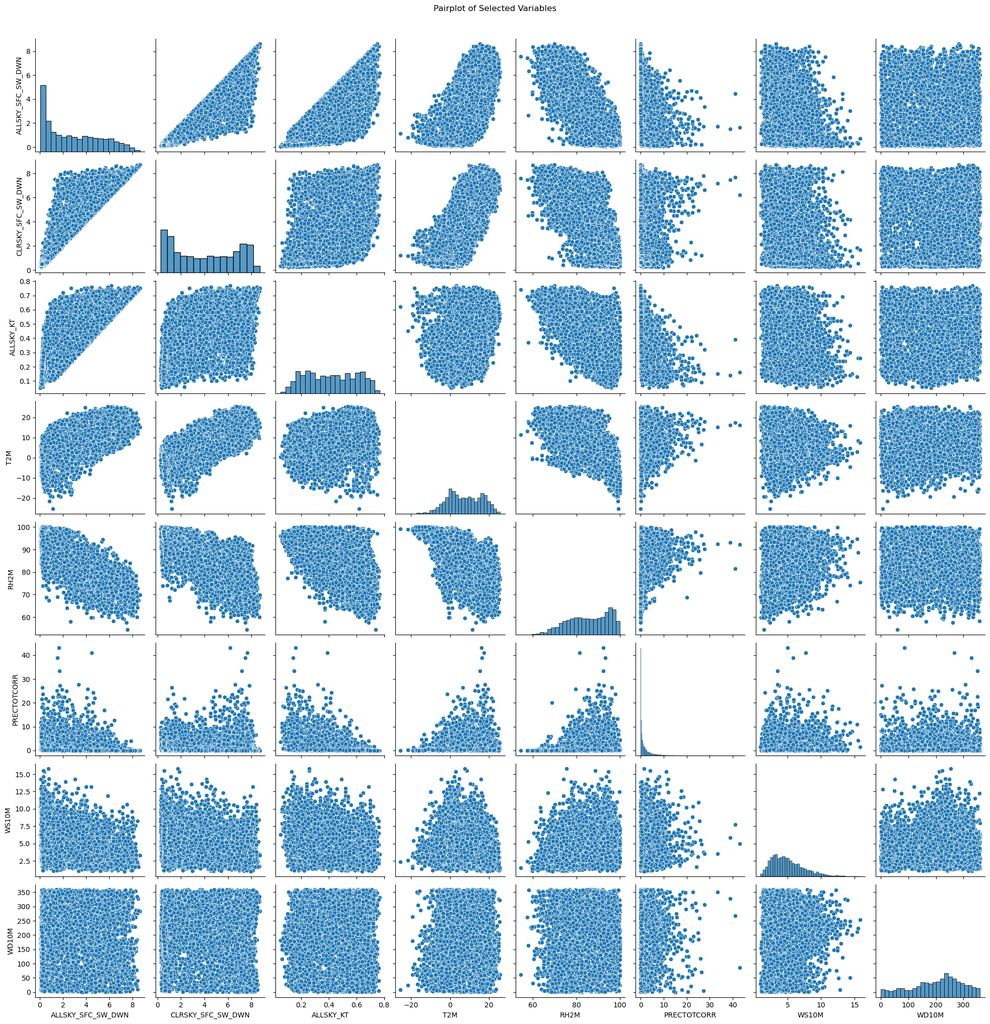

```python
sns.pairplot(dataset[selected_variables])
plt.suptitle('Pairplot of Selected Variables', y=1.02)
plt.show()
```

This pairplot visualizes the relationships among the selected meteorological variables. Each diagonal element displays the distribution (histogram) of a single variable, while each off-diagonal cell represents a scatter plot comparing two variables. Notably, strong linear patterns are visible between ALLSKY_SFC_SW_DWN (total shortwave radiation under all-sky conditions) and variables like ALLSKY_KT (clearness index) and CLRSKY_SFC_SW_DWN (clear-sky radiation), indicating high correlations. While these strong relationships may be useful for prediction, they also raise concerns about data leakage if any of these variables are derived from or directly influenced by the target. In contrast, variables such as WD10M (wind direction at 10m) and WS10M (wind speed at 10m) exhibit more scattered patterns, suggesting weaker or no clear correlation with the target.

Overall, this pairplot serves as a valuable tool for exploratory data analysis, helping to uncover feature redundancy, detect strong linear or nonlinear associations, and assess potential multicollinearity among predictors. It guides the feature selection process by highlighting which variables may offer unique information and which may overlap significantly with others. This understanding is essential for building robust and interpretable models, especially in time series or regression tasks where overfitting and multicollinearity can compromise model performance and generalizability.

```python
# Create scatter matrix
fig = px.scatter_matrix(
    dataset,
    dimensions=['T2M', 'RH2M', 'WS10M', 'PS', 'ALLSKY_SFC_SW_DWN'],
    color='City',
    title="'T2M', 'RH2M', 'WS10M', 'PS', 'ALLSKY_SFC_SW_DWN' Variables Correlation Matrix",
    labels={col: col for col in dataset.columns},
    height=800)

# Add correlation annotations
fig.update_traces(
    diagonal_visible=False,
    showupperhalf=False,
    marker=dict(
        size=4,
        opacity=0.5,
        line=dict(width=0.5, color='DarkSlateGrey')))

# Add density plots to diagonal
fig.update_layout(
    plot_bgcolor='white',
    title_font_size=20)



fig.show()
```

[interactive chart not shown]

```python
# Create bins for temperature and wind speed
temp_bins = pd.cut(dataset['T2M'], bins=10)
wind_bins = pd.cut(dataset['WS10M'], bins=10)

# Pivot the data
pivot_table = dataset.pivot_table(
    values='ALLSKY_SFC_SW_DWN',
    index=temp_bins,
    columns=wind_bins,
    aggfunc='mean')

# Convert index and columns to strings for better axis labels
pivot_table.index = pivot_table.index.astype(str)
pivot_table.columns = pivot_table.columns.astype(str)

# Create the heatmap using Plotly
fig = go.Figure(data=go.Heatmap(
    z=pivot_table.values,
    x=pivot_table.columns,
    y=pivot_table.index,
    colorscale='Viridis',
    colorbar=dict(title='Solar Radiation<br>(kW-hr/m²/day)')))

fig.update_layout(
    title='Solar Irradiance by Temperature and Wind Speed',
    xaxis_title='Wind Speed at 10m (WS10M) [m/s]',
    yaxis_title='Air Temperature at 2m (T2M) [°C]',
    height=500)

fig.show()
```

[interactive chart not shown]

This heatmap illustrates the relationship between solar irradiance (ALLSKY_SFC_SW_DWN), air temperature at 2 meters (T2M), and wind speed at 10 meters (WS10M) across the dataset. The most prominent trend is that solar radiation increases consistently with higher temperatures, peaking in the warmest bin (above ~20°C). Conversely, wind speed has a subtler, less consistent influence, with slightly higher solar radiation at lower to moderate wind speeds (2–6 m/s) and a notable decline as wind speeds increase beyond ~9 m/s. This suggests that while temperature strongly correlates with solar energy potential, high wind speeds may be associated with atmospheric conditions like increased cloud cover, which reduces incoming solar radiation.

```python
# Create 3D scatter plot with enhanced visuals
fig = px.scatter_3d(
    dataset,
    x='WS10M',  # Wind Speed at 10m
    y='T2M',    # Air Temperature at 2m
    z='ALLSKY_SFC_SW_DWN',  # Solar Radiation
    color='RH2M',  # Relative Humidity
    title="3D Relationship of Solar Radiation with Temperature, Wind Speed, and Humidity",
    labels={
        'WS10M': 'Wind Speed at 10m (m/s)',
        'T2M': 'Air Temperature at 2m (°C)',
        'ALLSKY_SFC_SW_DWN': 'Solar Radiation (kW-hr/m²/day)',
        'RH2M': 'Relative Humidity (%)'
    },
    color_continuous_scale='Turbo',  # Color scale
    opacity=0.7)

# Update marker size and appearance
fig.update_traces(marker=dict(size=3.5, line=dict(width=0)))

# Improve camera view and grid visibility
fig.update_layout(
    scene=dict(
        xaxis_title='Wind Speed at 10m (WS10M) [m/s]',
        yaxis_title='Air Temperature at 2m (T2M) [°C]',
        zaxis_title='Solar Radiation (kW-hr/m²/day)',
        xaxis=dict(showgrid=True, gridcolor='lightgrey'),
        yaxis=dict(showgrid=True, gridcolor='lightgrey'),
        zaxis=dict(showgrid=True, gridcolor='lightgrey')),
    scene_camera=dict(
        eye=dict(x=1.3, y=1.3, z=0.7)),
    coloraxis_colorbar=dict(
        title='Humidity (%)',
        tickvals=[50, 60, 70, 80, 90, 100]),
    margin=dict(l=0, r=0, t=60, b=0),
    height=500)

fig.show()
```

[interactive chart not shown]

This 3D scatter plot provides valuable insights into the complex interplay between solar radiation, air temperature, wind speed, and humidity:

- 1.Solar Radiation vs. Temperature (Z vs. Y axis): There is a clear positive correlation between solar radiation and temperature. As air temperature at 2 meters increases, solar irradiance also tends to rise. This is expected since sunnier days with stronger solar radiation naturally lead to higher ambient temperatures.
- 2.Solar Radiation vs. Wind Speed (Z vs. X axis): The relationship between wind speed and solar radiation appears more nuanced. The highest solar radiation values are generally observed at moderate wind speeds. Extremely low or high wind speeds are less associated with high solar irradiance, possibly due to atmospheric conditions:
  - Very low wind may be associated with fog or stagnant conditions that reduce sunlight.
  - Very high wind often correlates with cloudier or stormier weather, which blocks solar radiation.
- 3.Solar Radiation vs. Humidity (Color gradient): Humidity shows an inverse relationship with solar radiation. Points with high solar radiation (higher on the z-axis) are mostly colored blue-green, indicating lower relative humidity. In contrast, higher humidity values (yellow-red) cluster toward the lower solar radiation range. This makes sense because increased atmospheric moisture typically comes with cloud cover, which reduces the amount of solar energy reaching the surface.
- 4.Combined Effect: The plot suggests that optimal conditions for high solar radiation include:
  - Warm temperatures,
  - Moderate wind speeds, and
  - Low humidity.  
    These conditions are typical of clear, sunny days, which are most favorable for solar energy production.

In summary, this plot effectively illustrates how temperature and wind can support or suppress solar radiation depending on humidity, offering meaningful guidance for solar energy modeling and climatological studies.

```python
fig = go.Figure()

# Temperature Trace
fig.add_trace(go.Scatter(
    x=dataset.index,
    y=dataset['T2M'],
    name='Temperature [°C]',
    line=dict(color='#D32F2F', width=2.5),
    hovertemplate="<b>%{x|%Y-%m-%d %H:%M}</b><br>Temp: %{y:.1f}°C<extra></extra>",
    opacity=0.9))

# Humidity Trace
fig.add_trace(go.Scatter(
    x=dataset.index,
    y=dataset['RH2M'],
    name='Humidity [%]',
    yaxis='y2',
    line=dict(color='#1976D2', width=2.5),
    hovertemplate="Humidity: %{y:.1f}%<extra></extra>",
    opacity=0.9))

# Layout Enhancements
fig.update_layout(
    title=dict(
        text="<b>Temperature & Humidity Trends</b><br><sub>Hourly/Daily Observations</sub>",
        x=0.03,
        y=0.95,
        font=dict(size=24, color='#2C3E50')
    ),
    plot_bgcolor='#F5F5F5',
    paper_bgcolor='white',
    hovermode='x unified',
    margin=dict(t=100, b=80),
    legend=dict(
        orientation="h",
        yanchor="bottom",
        y=1.02,
        xanchor="right",
        x=1,
        bgcolor='rgba(255,255,255,0.9)'
    ),
    xaxis=dict(
        showgrid=True,
        gridcolor='white',
        rangeslider=dict(visible=True),
        rangeselector=dict(
            buttons=list([
                dict(count=1, label="1m", step="month", stepmode="backward"),
                dict(count=6, label="6m", step="month", stepmode="backward"),
                dict(count=1, label="YTD", step="year", stepmode="todate"),
                dict(step="all")
            ])
        )
    ),
    yaxis=dict(
        title=dict(text="Temperature [°C]", font=dict(color='#D32F2F')),
        showgrid=True,
        gridcolor='white',
        zeroline=False,
        range=[dataset['T2M'].min()-2, dataset['T2M'].max()+2]
    ),
    yaxis2=dict(
        title=dict(text="Humidity [%]", font=dict(color='#1976D2')),
        overlaying='y',
        side='right',
        showgrid=False,
        zeroline=False,
        range=[0, 100],  # Humidity percentage range
        rangemode='tozero'))

# Add reference lines
fig.add_hline(y=dataset['T2M'].mean(), line_dash="dot",
              line_color='#D32F2F', opacity=0.5,
              annotation_text=f"Avg Temp: {dataset['T2M'].mean():.1f}°C",
              annotation_position="bottom right")

fig.add_hline(y=dataset['RH2M'].mean(), line_dash="dot",
              line_color='#1976D2', opacity=0.5,
              annotation_text=f"Avg Humidity: {dataset['RH2M'].mean():.1f}%",
              annotation_position="top right")

# Add data source annotation
fig.add_annotation(
    text="Data Source: NASA POWER Project | Visualization: Milad Torabi & Jennifer Hu",
    xref="paper", yref="paper",
    x=0.5, y=-0.2,
    showarrow=False,
    font=dict(size=10, color='#7F8C8D'))

# Add time period annotation
fig.add_annotation(
    text=f"Period: {dataset.index.min().strftime('%Y-%m-%d')} to {dataset.index.max().strftime('%Y-%m-%d')}",
    xref="paper", yref="paper",
    x=0.5, y=-0.15,
    showarrow=False,
    font=dict(size=10, color='#7F8C8D'))

fig.show()
```

[interactive chart not shown]

```python
# having a copy of the main dataset for this task , in order not to change the original one
dataset_resetindex= dataset.copy()

# Categorize into Season
def get_season(month):
    if month in ['December', 'January', 'February']:
        return 'Winter'
    elif month in ['March', 'April', 'May']:
        return 'Spring'
    elif month in ['June', 'July', 'August']:
        return 'Summer'
    else:
        return 'Autumn'

dataset_resetindex['Season'] = dataset['Month'].apply(get_season)

# Rename date column if needed
dataset_resetindex = dataset_resetindex.reset_index().rename(columns={'DATE': 'Date'})

# Create the interactive plot
fig = px.scatter(
    dataset_resetindex,
    x='T2M',
    y='ALLSKY_SFC_SW_DWN',
    color='Season',
    facet_col='City',
    hover_data=['Date', 'RH2M', 'WS10M'],  # using Date column in hover
    title='Temperature vs Solar Irradiance by City and Season',
    labels={
        'T2M': 'Temperature (°C)',
        'ALLSKY_SFC_SW_DWN': 'Solar Irradiance (kW-hr/m²/day)'
    },
    category_orders={
        'Season': ['Winter', 'Spring', 'Summer', 'Autumn'],
        'City': ['Vilnius', 'Tallinn', 'Riga']
    },
    opacity=0.7,
    height=500)

# Customize layout
fig.update_layout(
    legend_title_text='Season',
    plot_bgcolor='white',
    hovermode='closest')

fig.for_each_annotation(lambda a: a.update(text=a.text.split("=")[-1]))
fig.update_xaxes(showgrid=True, gridwidth=0.5, gridcolor='LightGrey')
fig.update_yaxes(showgrid=True, gridwidth=0.5, gridcolor='LightGrey')
fig.show()
```

[interactive chart not shown]

This scatter plot illustrates the seasonal relationship between air temperature (°C) and solar irradiance (kW-hr/m²/day) across Vilnius, Tallinn, and Riga. Each subplot corresponds to a city, and the data points are color-coded by season. Across all three cities, a clear seasonal pattern emerges:

- Summer (green) shows the highest solar irradiance, particularly at warmer temperatures (10°C to 25°C), reflecting longer, sunnier days.
- Spring (red) follows with moderately high radiation values at milder temperatures, indicating the seasonal transition.
- Autumn (purple) exhibits lower irradiance compared to spring despite similar temperature ranges, likely due to shorter daylight hours.
- Winter (blue) consistently displays both low temperatures and minimal solar radiation, as expected from the coldest, darkest months.

The overall distribution highlights how seasonality significantly influences the amount of solar energy received, even when temperatures overlap — with summer delivering the strongest irradiance at similar or even lower temperatures than spring or autumn. This plot is useful for identifying the best seasons for solar energy potential in each city.

### Understanding the Trend Component in Seasonal Decomposition

The trend in the followin analysis comes from seasonal decomposition, which breaks a time series into three main components:

$$ Y_t = \text{Trend}_t + \text{Seasonal}_t + \text{Residual}_t $$

Where:

- Y(t) = Original time series (e.g., ALLSKY_SFC_SW_DWN)
- Trend(t) = Underlying long-term movement in the data
- Seasonal(t)= Seasonal component
- Residual(t) = Remaining noise and random fluctuations

How the Trend is Calculated?

1. Smoothing with a Moving Average  
   To extract the trend component, seasonal_decompose() smooths the time series using a moving average over a fixed period (in our case, 365 days for a yearly cycle).

For an additive model:

$$ \text{Trend}_t = \frac{1}{N} \sum_{i=t-k}^{t+k} Y_i $$

where:

- 𝑁 is the window size (365 for yearly data)
- 𝑘 is half the window size
- The sum is taken over a centered moving average to remove seasonal effects.  
  This moving average filters out short-term fluctuations and shows the underlying trend.
2. Handling Missing Edges with Extrapolation When applying a moving average, the trend calculation lacks values at the beginning and end of the series. To fix this, we used this code:
- " seasonal_decompose(city_series, model='additive', period=365, extrapolate_trend='freq') " which fills missing trend values at the edges using interpolation.

```python
# Create a subplot with 1 row and 2 columns
fig = make_subplots(rows=3, cols=1,
                    subplot_titles=['Trend of ALLSKY_SFC_SW_DWN for All Cities',
                                    'Trend of CLRSKY_SFC_SW_DWN for All Cities',
                                    'Trend of ALLSKY_KT for All Cities'], vertical_spacing=0.05)

def Plot_trend(variable):

    trend_data = []
    cities = dataset['City'].unique()

    for city in cities:
        # Extract city's time series
        city_series = dataset[dataset['City'] == city][variable]

        # Ensure the index is a DatetimeIndex and set the frequency
        city_series = city_series.asfreq('D')

        # Perform seasonal decomposition with trend extrapolation
        decomposition = seasonal_decompose(city_series, model='additive', period=365, extrapolate_trend='freq')

        # Extract trend component
        trend_df = decomposition.trend.reset_index()
        trend_df.columns = ['Date', 'Trend']
        trend_df['City'] = city

        # Drop NaN values from the trend component
        trend_df = trend_df.dropna()

        trend_data.append(trend_df)

    # Combine all city trends
    trend_all_cities = pd.concat(trend_data, ignore_index=True)

    return trend_all_cities

# plot ALLSKY_SFC_SW_DWN trend
ALLSKY_SFC_SW_DWN_trend = Plot_trend('ALLSKY_SFC_SW_DWN')
ALLSKY_SFC_SW_DWN_fig = px.line(ALLSKY_SFC_SW_DWN_trend, x='Date', y='Trend', color='City',
              title='Trend of ALLSKY_SFC_SW_DWN for All Cities')
for trace in ALLSKY_SFC_SW_DWN_fig.data:
    fig.add_trace(trace, row=1, col=1)

# plot CLRSKY_SFC_SW_DWN trend
CLRSKY_SFC_SW_DWN_trend = Plot_trend('CLRSKY_SFC_SW_DWN')
CLRSKY_SFC_SW_DWN_fig = px.line(CLRSKY_SFC_SW_DWN_trend, x='Date', y='Trend', color='City',
              title='Trend of ALLSKY_SFC_SW_DWN for All Cities')
for trace in CLRSKY_SFC_SW_DWN_fig.data:
    trace.showlegend = False  # Hide legend for this set
    fig.add_trace(trace, row=2, col=1)

# plot ALLSKY_KT trend
ALLSKY_KT_trend = Plot_trend('ALLSKY_KT')
ALLSKY_KT_fig = px.line(ALLSKY_KT_trend, x='Date', y='Trend', color='City',
              title='Trend of ALLSKY_KT for All Cities')
for trace in ALLSKY_KT_fig.data:
    trace.showlegend = False  # Hide legend for this set
    fig.add_trace(trace, row=3, col=1)

# Update layout to include legend
fig.update_layout(
    title="Trend of Solar-related variables ALLSKY_SFC_SW_DWN, CLRSKY_SFC_SW_DWN, and ALLSKY_KT for Vilnius, Tallinn, and Riga",
    title_font=dict(size=13),
    showlegend=True,
    height=1000)

# Show the plot
fig.show()
```

[interactive chart not shown]

This figure presents the seasonally adjusted trends of three key solar-related variables — ALLSKY_SFC_SW_DWN, CLRSKY_SFC_SW_DWN, and ALLSKY_KT — across Vilnius, Tallinn, and Riga from 2018 to 2022.

- ALLSKY_SFC_SW_DWN (Top Panel):  
  This represents the total surface shortwave downward irradiance (solar radiation reaching the surface under all sky conditions). Across all three cities, a dip is observed around early 2021, possibly due to atmospheric anomalies or cloud cover. After this period, there’s a consistent increasing trend, suggesting a recovery or improved solar availability.
- CLRSKY_SFC_SW_DWN (Middle Panel):  
  This variable captures solar radiation under clear-sky conditions (i.e., assuming no clouds). Trends here are more stable, as expected, since they are less influenced by variable weather. Vilnius consistently has the highest clear-sky values, followed by Riga and Tallinn, likely due to geographic and atmospheric differences.
- ALLSKY_KT (Bottom Panel):  
  The clearness index (KT), defined as the ratio of actual to clear-sky radiation, fluctuates more and reflects how transparent the atmosphere is. All cities show lower KT around 2020–2021, indicating higher cloudiness or atmospheric attenuation, followed by an upward trend in 2022, suggesting clearer skies or improved atmospheric transmission.
- Overall Insights: All cities exhibit seasonal and interannual variability in solar irradiance.  
  There is a notable upward trend in 2022 for all variables, potentially hinting at improved solar resource availability.  
  Vilnius tends to receive slightly higher solar irradiance, while Tallinn shows the lowest values, likely due to its higher latitude and weather patterns.

# 3.Predictive Analytics

#### Can we predict solar radiation based on other meteorological data that impact renewable energy generation and potential?

Now that we've explored trends and investigated variable interactions, we’ll move into the prediction and forecasting phase. This step focuses on building models to estimate or forecast solar radiation, specifically the ALLSKY_SFC_SW_DWN variable—which represents the total shortwave (SW) radiation received at the surface under all-sky conditions (including clouds). To approach this, we can:

- 1.Use Generic Regression (“Prediction”):  
  When we want a single-day estimate based on today’s measurements (no explicit multi-step horizon).
- 2.Use Time-Series Forecasting (“Forecast”):  
  When we explicitly model temporal dynamics to predict future values of ALLSKY_SFC_SW_DWN over a horizon (e.g., the next 7 or 30 days).

**Step 1: Choose the Forecasting Horizon**  
Is daily prediction a good horizon?  
Yes and no:  
Yes, if the goal is to provide short-term insights for energy planning.  
Yes, if the dataset contains enough past data points to capture meaningful patterns.  
No, if the goal is long-term prediction (seasonal or yearly trends), where aggregating to weekly or monthly time frames may be more effective.  
For the scope of this project, we select Generic Regression (“Prediction”) to estimate the solar radiation value based on today’s meteorological measurements over the course of one year.

**Step 2: Select Suitable Models**  
Since we have multiple meteorological predictors, we can explore various regression models:

- Machine Learning Models:  
  Random Forest Regression: Handles nonlinear relationships well and works effectively with multiple predictors.  
  Gradient Boosting (e.g., XGBoost, LightGBM, CatBoost)  
  Support Vector Regression (SVR)  
  These algorithms are well-suited for using a full set of meteorological variables as predictors.

In this project, we ensembled 4 different regression models via stacking in order to predict the solar radiation. these models are:

- 1. RandomForest
- 2. GradientBoosting
- 3. Support Vector Regressor
- 4. Multi‑Layer Perceptron(MLP)

Since we have a time dependant model, We use a time‑series–aware cross‑validation to better generelize the model on data 2018–2021 window to tune hyperparameters, and 2022 data remains untouched for final testing. Therefore we:

- 1. Train and validate on 2018–2021 to learn patterns based on the following table guideline.
- 2. Test on 2022 only once for an unbiased performance estimate: We are training three completely separate stacking ensembles: Therefore, Each model learns the idiosyncrasies of its own city’s climate, rather than forcing one model to fit all three.

[output not shown]

**Putting it all together**

- Diversity: By mixing bagging (RandomForest), boosting (GradientBoosting), kernel methods (Support Vector Regressor), and a neural net (MLP), we give the stacker richly varied perspectives on the data.
- Leak‑free training: The manual CV loop ensures no model ever “sees” its own hold‑out predictions during meta‑model fitting.
- Robust combination: RidgeCV learns to down‑weight any base learner whose predictions are noisy or redundant, yielding a final ensemble that often outperforms any single constituent.  
  With this architecture, we harness complementary strengths:
- Variance reduction from tree-based methods (Random Forest),
- Bias reduction from boosting (Gradient Boosting),
- Smooth function approximation from SVR, and
- Flexible nonlinear transformations from MLP.  
  All are optimally blended by a regularized linear meta-learner.  
  Following this cell, we implement the pipeline.  
  (Note: For models that require normalized input—such as MLP and SVR—we applied standardization using StandardScaler() within their individual pipelines inside the stack (estimators).)  
  inorder to better handle the data pipeline and prevent information from being unintentionally cross-pollinated across cities, we need to have 3 different data frame each for one city. We also use feature engineering in order to boost the performance of the models and take the advantage of features in a time seires fasion.

**Future Exploration: Long-Term Forecasting**  
For future work and long-term insights in energy planning, we can use forecasting techniques such as:

- Traditional Time Series Models:  
  ARIMA/SARIMA (Autoregressive Integrated Moving Average): Effective when solar radiation exhibits a clear seasonal pattern, and when relying solely on past solar radiation values for prediction (univariate approach).
- Deep Learning Models (for Advanced Forecasting):  
  LSTM (Long Short-Term Memory Networks)  
  Transformer Architecture  
  These models are ideal for leveraging temporal dependencies in the data and modeling complex sequential patterns. **Due to time constraints, we have placed this further exploration outside the scope of this project.**

```python
# Bird's view of the pipeline
# 1- Split by city and keep each city’s data completely separate.
# 2- Engineer only pure time-based features (year, month, day-of-year, ISO week) from the datetime index.
# 3- Chronologically split each city into a 2018–2021 training window and a 2022 hold-out test window.
# 4- Drop any features that directly leak the target (ALLSKY_SFC_SW_DWN) or are derived from it.
# 5- Filter our TimeSeriesSplit so that every training fold covers at least 365 days (one full seasonal cycle).
# 6- Clone and fit a fresh stacking ensemble on each fold, ensuring no carry-over of learned state between folds.
# 7- Final retraining is done city-by-city—each clone is fit on its full 2018–2021 data, then immediately evaluated
#    on that same city’s 2022 data.

# suppress only MLP convergence warnings
warnings.filterwarnings("ignore", category=ConvergenceWarning)

# ---------------------------
# 1. Data Preparation
# ---------------------------

df= dataset.copy()

# Split dataset by city
df_Vilnius = df[df['City']  == 'Vilnius' ].drop('City',axis=1)
df_Tallinn = df[df['City']  == 'Tallinn' ].drop('City',axis=1)
df_Riga = df[df['City']  == 'Riga' ].drop('City',axis=1)


# ---------------------------
# 2. Time-Series Feature Engineering
# ---------------------------

def create_features(df):
    """Create time features"""
    # Time-based features
    df = df.assign(
        Year = df.index.year,
        Month = df.index.month,
        DayOfYear = df.index.dayofyear,
        WeekOfYear = df.index.isocalendar().week.astype(int) )
    return df

df_Vilnius=create_features(df_Vilnius)
df_Tallinn=create_features(df_Tallinn)
df_Riga = create_features(df_Riga)


# ---------------------------
# 3. Temporal Data Splitting
# ---------------------------

# Split train and test set
def trainandtest_split(df):
    train_mask = df.index.year < 2022
    train_df = df[train_mask].copy() # ['2018-01-01':'2021-12-31']
    test_df = df[~train_mask].copy() # ['2022-01-01':'2022-12-31']
    return train_df , test_df


train_df_Vilnius, test_df_Vilnius = trainandtest_split(df_Vilnius)
train_df_Tallinn, test_df_Tallinn = trainandtest_split(df_Tallinn)
train_df_Riga, test_df_Riga = trainandtest_split(df_Riga)


# ---------------------------
# 4. Feature/Target Definition
# ---------------------------

# Exclude the target and all the variable that are derived from it(drop leakage/redundant features)
drop_columns = ['ALLSKY_SFC_SW_DWN', 'CLRSKY_SFC_SW_DWN', 'ALLSKY_KT',
                'ALLSKY_SFC_LW_DWN', 'ALLSKY_SFC_UVA', 'ALLSKY_SFC_UV_INDEX']

def Feature_Target_Definition(df):

    X = df.drop(columns = drop_columns).select_dtypes(include=np.number) # Ensure numeric features only
    y = df['ALLSKY_SFC_SW_DWN']

    return X , y

X_train_df_Vilnius, y_train_df_Vilnius = Feature_Target_Definition(train_df_Vilnius)
X_test_df_Vilnius, y_test_df_Vilnius = Feature_Target_Definition(test_df_Vilnius)

X_train_df_Tallinn, y_train_df_Tallinn = Feature_Target_Definition(train_df_Tallinn)
X_test_df_Tallinn, y_test_df_Tallinn = Feature_Target_Definition(test_df_Tallinn)

X_train_df_Riga, y_train_df_Riga = Feature_Target_Definition(train_df_Riga)
X_test_df_Riga, y_test_df_Riga = Feature_Target_Definition(test_df_Riga)


# ---------------------------
# 5. Time-Series cross-validation
# ---------------------------

# Use expanding window cross-validation
tscv = TimeSeriesSplit(n_splits=7) # we set n_splits=7 by trial and error because the model can see at least one full year
                                    # and in this way the number of folds and their sizes are resonalbe
def CV_Validation(X_trainval):
    # enforce minimum train size of one year (365 samples)
    min_train_size = 365
    all_splits = list(tscv.split(X_trainval))
    filtered_splits = [
        (train_idx, val_idx)
        for train_idx, val_idx in all_splits
        if len(train_idx) >= min_train_size]

    return filtered_splits


# ---------------------------
# 6. Define 4 base learners and StackingRegressor with RidgeCV meta‑learner
# ---------------------------

estimators = [
    ('rf',  RandomForestRegressor(n_estimators=200, random_state=42, n_jobs=-1)),
    ('gbr', GradientBoostingRegressor(n_estimators=200, learning_rate=0.05, random_state=42)),
    ('svr', Pipeline([
        ('scaler', StandardScaler()),
        ('svr', SVR(kernel='rbf', C=1.0, epsilon=0.1))
    ])),
    ('mlp', Pipeline([
        ('scaler', StandardScaler()),
        ('mlp', MLPRegressor(hidden_layer_sizes=(100,),
                             activation='relu',
                             solver='adam',
                             max_iter=500,
                             random_state=42))]))]


stack = StackingRegressor(
    estimators=estimators,
    final_estimator=RidgeCV(alphas=[0.1, 1.0, 10.0]),
    cv=None,            # we'll do CV manually to wrap with tqdm
    passthrough=False)


# ---------------------------
# 7. Training using Cross-validation loop
# ---------------------------

def train_the_data(X_trainval,y_trainval,City):
    fold_metrics = []  # List to store metrics for each fold

    print("Starting TimeSeriesSplit Cross-validation on 2018–2021:")
    filtered_splits_called = CV_Validation(X_trainval)

    for fold, (train_idx, val_idx) in enumerate(tqdm(filtered_splits_called, total=len(filtered_splits_called), desc="CV folds")):
        X_tr, X_val = X_trainval.iloc[train_idx], X_trainval.iloc[val_idx]
        y_tr, y_val = y_trainval.iloc[train_idx], y_trainval.iloc[val_idx]

        # Fit stacking on this fold
        stack_fold = clone(stack)
        stack_fold.fit(X_tr, y_tr)

        # Predict and evaluate
        y_pred = stack_fold.predict(X_val)

         # for some versions of scikit-learn the following code works instead of 'squared=False'
#       RMSE = np.sqrt(mean_squared_error(y_val, y_pred))
        RMSE   = mean_squared_error(y_val, y_pred, squared=False)
        MSE    = mean_squared_error(y_val, y_pred)
        MAE    = mean_absolute_error(y_val, y_pred)
        MAPE   = np.mean(np.abs((y_val - y_pred) / y_val)) * 100
        R2     = r2_score(y_val, y_pred)
        Explained_Var = explained_variance_score(y_val, y_pred)

        # Store metrics in a list of dicts
        fold_metrics.append({
            'City': City,
            'Fold': fold + 1,
            'RMSE': RMSE,
            'MSE': MSE,
            'MAE': MAE,
            'MAPE': MAPE,
            'R2': R2,
            'Explained_Var': Explained_Var})

        tqdm.write(f"[{City}] Fold Number {fold+1} RMSE: {RMSE:.3f} MAE: {MAE:.3f} R²: {R2:0.3f} ")

    metrics_df = pd.DataFrame(fold_metrics)

    return metrics_df
```

##### Explanation on how stacking works:

Stacking is an ensemble-learning technique that works in two “layers”:

- A. Base models (level-0 learners)  
  we have four different regressors: 1-RandomForest, 2-GradientBoosting, 3-SVR (with preprocessing), MLP (with preprocessing):
  - A.1 RandomForestRegressor ('rf'):
    - Type: Bagged ensemble of decision trees.
    - Key hyperparameters:
      - n_estimators=200: builds 200 distinct trees.
      - random_state=42: seeds the random splits for reproducibility.
      - n_jobs=-1: uses all CPU cores in parallel.
    - How it works:
      - Each tree sees a bootstrap sample of the data and a random subset of features at each split → decorrelated trees.
      - Final prediction = average of all 200 tree outputs → low variance, robust to noise
  - A.2 GradientBoostingRegressor ('gbr'):
    - Type: Stage‑wise additive modeling (“boosting”) of shallow trees.
    - Key hyperparameters:
      - n_estimators=200: number of boosting stages (trees).
      - learning_rate=0.05: shrinkage parameter scaling each tree’s contribution. Lower → more gradual fitting.
      - random_state=42: reproducible tree‑building order.
    - How it works
      - Trees are added sequentially; each new tree fits the residual error of the ensemble so far.
      - Smaller learning_rate + more n_estimators often yields better generalization at the cost of more compute.
  - A.3 Support Vector Regressor ('svr'):
    - Because SVMs are sensitive to feature scales, so we first standardize every feature to zero mean and unit variance.
    - SVR hyperparameters:
      - kernel='rbf': radial‑basis‑function kernel to capture non‑linear relationships.
      - C=1.0: regularization strength (trade‑off between flatness and training error).
      - epsilon=0.1: width of the “insensitive tube”—errors smaller than 0.1 aren’t penalized in the loss function.
    - How it works:
      - Finds a function that deviates by at most ε from the true targets—while keeping the function as flat (low‑complexity) as possible.
      - Good for capturing smooth, non‑linear trends that trees might miss.
  - A.4 Multi‑Layer Perceptron ('mlp'):
    - Why a pipeline? Neural nets also perform better when inputs are scaled.
    - Network architecture:
      - Input layer: one node per feature.
      - Hidden layer: 100 neurons with ReLU activation (hidden_layer_sizes=(100,)).
      - Output layer: single linear neuron (for regression).
    - Training details
      - solver='adam': adaptive moment estimation, efficient for medium‑sized datasets.
      - max_iter=500: up to 500 epochs; may raise a ConvergenceWarning if not fully converged.
      - random_state=42: reproducible weight initialization and data shuffling.

On each CV fold, each base model is trained on that fold’s training slice (X_tr, y_tr). Then it makes predictions on that fold’s hold-out slice (X_val). Those predictions are called out-of-fold (OOF) predictions. After we cycle through all folds, we end up with a full vector of OOF predictions for each base model (one prediction for every training row), but crucially never on data they were trained on.

- B. Meta-model (level-1 learner)  
  we take those OOF predictions as new features (one column per base model). we fit a simple model (here, RidgeCV) on those features to learn how best to combine the base-model outputs. Intuition: Ridge will learn weights w1, w2, w3, w4 so that:

$$ \hat{y} = w_1 \cdot \text{RF}_{\text{pred}} + w_2 \cdot \text{GBR}_{\text{pred}} + w_3 \cdot \text{SVR}_{\text{pred}} + w_4 \cdot \text{MLP}_{\text{pred}} $$

- (plus regularization to avoid overfitting).

**Final training :**  
Once our meta-model is tuned, we retrain all four base models on the entire 2018–2021 set and then fit the meta-model on their predictions on that same full set. At test time, we feed the test features through each base model to get four test-set predictions, then feed those four numbers into the Ridge meta-model to get our final ensemble prediction.

```python
metrics_df_Vilnius = train_the_data(X_train_df_Vilnius, y_train_df_Vilnius,'Vilnius')
metrics_df_Tallinn = train_the_data(X_train_df_Tallinn, y_train_df_Tallinn,'Tallinn')
metrics_df_Riga = train_the_data(X_train_df_Riga, y_train_df_Riga,'Riga')

print("\n✅ Model training completed successfully for all cities!")
```

```
Starting TimeSeriesSplit Cross-validation on 2018–2021:
```

```
[Vilnius] Fold Number 1 RMSE: 1.568 MAE: 1.228 R²: 0.594
[Vilnius] Fold Number 2 RMSE: 0.833 MAE: 0.615 R²: 0.829
[Vilnius] Fold Number 3 RMSE: 0.908 MAE: 0.683 R²: 0.838
[Vilnius] Fold Number 4 RMSE: 0.620 MAE: 0.425 R²: 0.917
[Vilnius] Fold Number 5 RMSE: 0.727 MAE: 0.557 R²: 0.892
[Vilnius] Fold Number 6 RMSE: 0.565 MAE: 0.428 R²: 0.927
Starting TimeSeriesSplit Cross-validation on 2018–2021:
```

```
[Tallinn] Fold Number 1 RMSE: 1.087 MAE: 0.817 R²: 0.817
[Tallinn] Fold Number 2 RMSE: 0.847 MAE: 0.597 R²: 0.843
[Tallinn] Fold Number 3 RMSE: 0.696 MAE: 0.509 R²: 0.928
[Tallinn] Fold Number 4 RMSE: 0.532 MAE: 0.368 R²: 0.940
[Tallinn] Fold Number 5 RMSE: 0.672 MAE: 0.511 R²: 0.927
[Tallinn] Fold Number 6 RMSE: 0.710 MAE: 0.523 R²: 0.888
Starting TimeSeriesSplit Cross-validation on 2018–2021:
```

```
[Riga] Fold Number 1 RMSE: 1.541 MAE: 1.142 R²: 0.628
[Riga] Fold Number 2 RMSE: 0.707 MAE: 0.518 R²: 0.885
[Riga] Fold Number 3 RMSE: 0.881 MAE: 0.643 R²: 0.867
[Riga] Fold Number 4 RMSE: 0.585 MAE: 0.443 R²: 0.923
[Riga] Fold Number 5 RMSE: 0.690 MAE: 0.496 R²: 0.914
[Riga] Fold Number 6 RMSE: 0.618 MAE: 0.459 R²: 0.911

✅ Model training completed successfully for all cities!
```

```python
# ---------------------------
# 8. Final Model Training on all of 2018–2021 and Test Set Evaluation on 2022 data
# ---------------------------

def Test_evaluation(model, X_test, y_test, City):

    test_metrics = []  # List to store metrics

    y_pred = model.predict(X_test)
     # for some versions of scikit-learn the following code works instead of 'squared=False'
#   RMSE = np.sqrt(mean_squared_error(y_test, y_pred))
    RMSE   = mean_squared_error(y_test, y_pred, squared=False)
    MSE    = mean_squared_error(y_test, y_pred)
    MAE    = mean_absolute_error(y_test, y_pred)
    MAPE   = np.mean(np.abs((y_test - y_pred) / y_test)) * 100
    R2     = r2_score(y_test, y_pred)
    Explained_Var = explained_variance_score(y_test, y_pred)

    # Store metrics in a list of dicts
    test_metrics.append({
            'City': City,
            'Fold': 'Test set',
            'RMSE': RMSE,
            'MSE': MSE,
            'MAE': MAE,
            'MAPE': MAPE,
            'R2': R2,
            'Explained_Var': Explained_Var})


    print(f"[{City}] Test RMSE: {RMSE:.3f}  MAE: {MAE:.3f}  R²: {R2:.3f}")

    test_metrics_df = pd.DataFrame(test_metrics)

    return test_metrics_df


# Vilnius
stack_v = clone(stack)
stack_v.fit(X_train_df_Vilnius, y_train_df_Vilnius)
Test_Result_Vilnius = Test_evaluation(stack_v, X_test_df_Vilnius, y_test_df_Vilnius, "Vilnius")

# for Tallinn
stack_t = clone(stack)
stack_t.fit(X_train_df_Tallinn, y_train_df_Tallinn)
Test_Result_Tallinn = Test_evaluation(stack_t, X_test_df_Tallinn, y_test_df_Tallinn, "Tallinn")


# for Riga
stack_r = clone(stack)
stack_r.fit(X_train_df_Riga, y_train_df_Riga)
Test_Result_Riga = Test_evaluation(stack_r, X_test_df_Riga, y_test_df_Riga, "Riga" )


# Persist each fitted model for later use
joblib.dump(stack_v, "stack_vilnius_2018_2021.pkl")
joblib.dump(stack_t, "stack_tallinn_2018_2021.pkl")
joblib.dump(stack_r, "stack_riga_2018_2021.pkl")

print("\n✅ All models have been trained on 2018–2021 data, evaluated on 2022 test data, and saved successfully for Vilnius, Tallinn, and Riga.")
```

```
[Vilnius] Test RMSE: 0.585  MAE: 0.422  R²: 0.933
[Tallinn] Test RMSE: 0.658  MAE: 0.440  R²: 0.925
[Riga] Test RMSE: 0.646  MAE: 0.459  R²: 0.925

✅ All models have been trained on 2018–2021 data, evaluated on 2022 test data, and saved successfully for Vilnius, Tallinn, and Riga.
```

```python
# Metrics results for Tallinn
combined_metrics_df = pd.concat(
    [metrics_df_Vilnius, metrics_df_Tallinn, metrics_df_Riga, Test_Result_Vilnius , Test_Result_Tallinn, Test_Result_Riga],
    axis=0,           # 0 = row-wise (vertical)
    ignore_index=True)
combined_metrics_df
```

|  | City | Fold | RMSE | MSE | MAE | MAPE | R2 | Explained_Var |
| --- | --- | --- | --- | --- | --- | --- | --- | --- |
| 0 | Vilnius | 1 | 1.568270 | 2.459471 | 1.227999 | 37.619940 | 0.593938 | 0.817257 |
| 1 | Vilnius | 2 | 0.832714 | 0.693413 | 0.615242 | 45.745705 | 0.828760 | 0.854892 |
| 2 | Vilnius | 3 | 0.908162 | 0.824758 | 0.683202 | 30.385962 | 0.837694 | 0.847247 |
| 3 | Vilnius | 4 | 0.620138 | 0.384571 | 0.425060 | 39.163852 | 0.917356 | 0.922224 |
| 4 | Vilnius | 5 | 0.727364 | 0.529058 | 0.557460 | 25.251861 | 0.891526 | 0.898577 |
| 5 | Vilnius | 6 | 0.564912 | 0.319125 | 0.427998 | 41.108140 | 0.926540 | 0.932790 |
| 6 | Tallinn | 1 | 1.087107 | 1.181802 | 0.816912 | 45.109520 | 0.817476 | 0.847549 |
| 7 | Tallinn | 2 | 0.847382 | 0.718055 | 0.596652 | 116.492093 | 0.842723 | 0.864722 |
| 8 | Tallinn | 3 | 0.696206 | 0.484703 | 0.508973 | 40.606250 | 0.928260 | 0.928740 |
| 9 | Tallinn | 4 | 0.532057 | 0.283085 | 0.368267 | 34.644370 | 0.939871 | 0.939882 |
| 10 | Tallinn | 5 | 0.672289 | 0.451972 | 0.511349 | 37.207008 | 0.926902 | 0.937324 |
| 11 | Tallinn | 6 | 0.710412 | 0.504685 | 0.523133 | 60.665872 | 0.888187 | 0.929404 |
| 12 | Riga | 1 | 1.541131 | 2.375086 | 1.141712 | 39.285894 | 0.627587 | 0.721104 |
| 13 | Riga | 2 | 0.706875 | 0.499672 | 0.517846 | 56.733062 | 0.884581 | 0.887076 |
| 14 | Riga | 3 | 0.880653 | 0.775550 | 0.642800 | 28.985125 | 0.866948 | 0.879544 |
| 15 | Riga | 4 | 0.584517 | 0.341661 | 0.443130 | 62.380187 | 0.922818 | 0.934995 |
| 16 | Riga | 5 | 0.690024 | 0.476133 | 0.496183 | 23.799310 | 0.913913 | 0.914296 |
| 17 | Riga | 6 | 0.618037 | 0.381970 | 0.459477 | 49.780071 | 0.911400 | 0.938910 |
| 18 | Vilnius | Test set | 0.584721 | 0.341899 | 0.421547 | 25.582210 | 0.933146 | 0.933522 |
| 19 | Tallinn | Test set | 0.657837 | 0.432749 | 0.440240 | 22.111028 | 0.924941 | 0.926290 |
| 20 | Riga | Test set | 0.645535 | 0.416715 | 0.458544 | 24.303519 | 0.924753 | 0.924982 |

# Results explanations and Visualizations

Below is a consolidated summary table of the models results, showing for each city the overall CV RMSE (mean ± std), and the final 2022 test metrics (RMSE, MAE, R²):

### Model Performance Summary

| City | CV RMSE (mean ± std) | Test RMSE | Test MAE | Test R² |
| --- | --- | --- | --- | --- |
| Vilnius | 0.870 ± 0.333 | 0.585 | 0.422 | 0.933 |
| Tallinn | 0.758 ± 0.174 | 0.658 | 0.440 | 0.925 |
| Riga | 0.837 ± 0.329 | 0.646 | 0.459 | 0.925 |

###### The fold-wise CV RMSEs:

| City | Fold 1 RMSE | Fold 2 RMSE | Fold 3 RMSE | Fold 4 RMSE | Fold 5 RMSE | Fold 6 RMSE | CV RMSE (μ ± σ) | Test RMSE | Test MAE | Test R² |
| --- | --- | --- | --- | --- | --- | --- | --- | --- | --- | --- |
| Vilnius | 1.568 | 0.833 | 0.908 | 0.620 | 0.727 | 0.565 | 0.870 ± 0.333 | 0.585 | 0.422 | 0.933 |
| Tallinn | 1.087 | 0.847 | 0.696 | 0.532 | 0.672 | 0.710 | 0.758 ± 0.174 | 0.658 | 0.440 | 0.925 |
| Riga | 1.541 | 0.707 | 0.881 | 0.585 | 0.690 | 0.618 | 0.837 ± 0.329 | 0.646 | 0.459 | 0.925 |

For each city-specific stacking ensemble, we ran a 6-fold expanding-window CV on 2018–2021 and recorded fold-level RMSEs. The “CV RMSE (μ ± σ)” column shows the mean and standard deviation of those six RMSE values. Finally, each model was retrained on all 2018–2021 data and evaluated on the 2022 hold-out set, with test-set RMSE, MAE and R² reported in the last three columns.

```
   City  CV_RMSE_mean  CV_RMSE_std  Test_RMSE  Test_MAE  Test_R2
Vilnius         0.870        0.333      0.585     0.422    0.933
Tallinn         0.758        0.174      0.658     0.440    0.925
   Riga         0.837        0.329      0.646     0.459    0.925
```

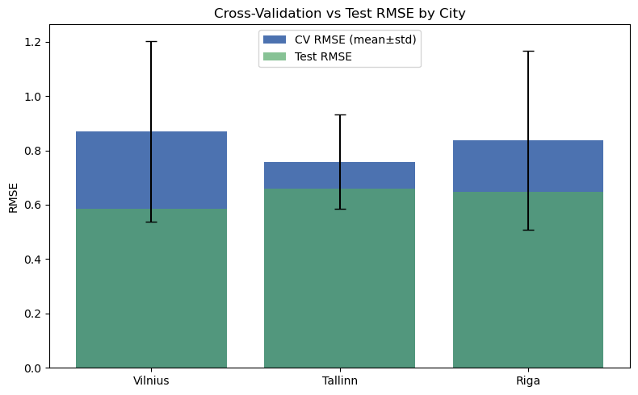

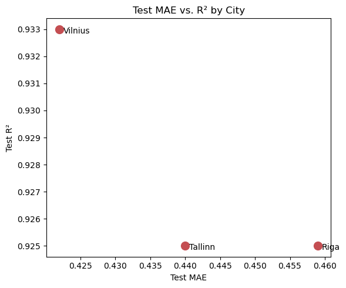

```python
# 1) Build the summary DataFrame
summary = pd.DataFrame({
    'City': ['Vilnius','Tallinn','Riga'],
    'CV_RMSE_mean': [0.870, 0.758, 0.837],
    'CV_RMSE_std':  [0.333, 0.174, 0.329],
    'Test_RMSE':    [0.585, 0.658, 0.646],
    'Test_MAE':     [0.422, 0.440, 0.459],
    'Test_R2':      [0.933, 0.925, 0.925]
})

# 2) Display the table
print(summary.to_string(index=False))

# 3) Plot CV vs Test RMSE with error bars
fig, ax = plt.subplots(figsize=(8, 5))
x = summary['City']
ax.bar(x, summary['CV_RMSE_mean'], yerr=summary['CV_RMSE_std'],
       capsize=5, label='CV RMSE (mean±std)', color='#4C72B0')
ax.bar(x, summary['Test_RMSE'], alpha=0.7, label='Test RMSE', color='#55A868')
ax.set_ylabel('RMSE')
ax.set_title('Cross-Validation vs Test RMSE by City')
ax.legend()
plt.tight_layout()
plt.show()

# 4) Scatter of Test R² vs Test MAE
fig, ax = plt.subplots(figsize=(6, 5))
ax.scatter(summary['Test_MAE'], summary['Test_R2'], s=100, color='#C44E52')
for i, city in enumerate(summary['City']):
    ax.annotate(city, (summary['Test_MAE'][i], summary['Test_R2'][i]),
                textcoords="offset points", xytext=(5,-5))
ax.set_xlabel('Test MAE')
ax.set_ylabel('Test R²')
ax.set_title('Test MAE vs. R² by City')
plt.tight_layout()
plt.show()
```

```python
# 1) Fit each city’s stacking model and get predictions
pred_v = pd.Series(stack_v.predict(X_test_df_Vilnius),
                   index=X_test_df_Vilnius.index,
                   name='Predicted')

pred_t = pd.Series(stack_t.predict(X_test_df_Tallinn),
                   index=X_test_df_Tallinn.index,
                   name='Predicted')

pred_r = pd.Series(stack_r.predict(X_test_df_Riga),
                   index=X_test_df_Riga.index,
                   name='Predicted')

# 2) Bundle up actual & predicted
cities = {
    'Vilnius': (y_test_df_Vilnius.rename('Actual'), pred_v),
    'Tallinn': (y_test_df_Tallinn.rename('Actual'), pred_t),
    'Riga':    (y_test_df_Riga.rename('Actual'),    pred_r)}

# 3) Plot each separately
for city, (actual, predicted) in cities.items():
    fig = go.Figure()
    fig.add_trace(go.Scatter(
        x=actual.index, y=actual,
        mode='lines', name='Actual',
        line=dict(color='#1f77b4', width=2),
        hovertemplate='Date: %{x|%Y-%m-%d}<br>Actual: %{y:.2f}<extra></extra>'))
    fig.add_trace(go.Scatter(
        x=predicted.index, y=predicted,
        mode='lines', name='Predicted',
        line=dict(color='#ff7f0e', width=2, dash='dot'),
        hovertemplate='Date: %{x|%Y-%m-%d}<br>Predicted: %{y:.2f}<extra></extra>'))

    fig.update_layout(
        title=f'{city} — Actual vs Predicted Daily Solar Radiation (2022)',
        xaxis_title='Date',
        yaxis_title='ALLSKY_SFC_SW_DWN (kW-hr/m²/day)',
        template='plotly_white',
        hovermode='x unified',
        legend=dict(orientation='h', yanchor='bottom', y=1.02, xanchor='right', x=1),
        margin=dict(l=50, r=20, t=80, b=50),
        height=400)

    # range selector / slider:
    fig.update_xaxes(
        rangeslider_visible=True,
        rangeselector=dict(
            buttons=[
                dict(count=7, label="1w", step="day", stepmode="backward"),
                dict(count=1, label="1m", step="month", stepmode="backward"),
                dict(count=3, label="3m", step="month", stepmode="backward"),
                dict(step="all")] ))

    fig.update_layout(
        hoverlabel=dict(bgcolor="white", font_size=12, font_family="Arial"))

    fig.show()
```

[interactive chart not shown]

**Vilnius**  
In Vilnius, we see a similarly tight fit: the stacked ensemble reproduces the characteristic summer plateau of high solar radiation and the jagged daily swings caused by passing weather fronts. While there are a handful of days (notably in late spring and early autumn) where the model slightly underestimates brief spikes, the predicted curve (orange dots) remains within about ±1 kW-hr/m²/day of the true values almost everywhere. This consistency confirms that seasonal features plus meteorological inputs give the model robust generalization for Vilnius’s solar profile.

**Tallinn**  
In Tallinn, the model closely tracks the seasonal rise and fall of daily solar radiation, capturing the steep increase from near‐zero winter values in January up to summer peaks around 8 kW-hr/m²/day in June and July, then gracefully following the autumn decline back toward winter lows. Small timing offsets appear on some cloudy days (e.g. under- or over-predictions by ~0.5–1 kW-hr/m²/day), but overall the dotted orange forecast line hugs the blue actual line throughout the year, demonstrating both strong seasonal learning and day-to-day variability in the model’s predictions.

**Riga**  
For Riga, the forecast again aligns strongly with reality: winter values near zero, a clear ascent through spring, and a broad summer maximum around 7–8 kW-hr/m²/day. The model handles Riga’s midseason variability well, though you can spot occasional underpredictions during sudden clear-sky days in May and slight overpredictions during intermittent cloud cover in late summer. Overall, the forecasted (dotted) and actual (solid) lines overlap so tightly that even the brief dips and peaks are faithfully mirrored, underscoring the model’s ability to learn local seasonal and daily patterns.

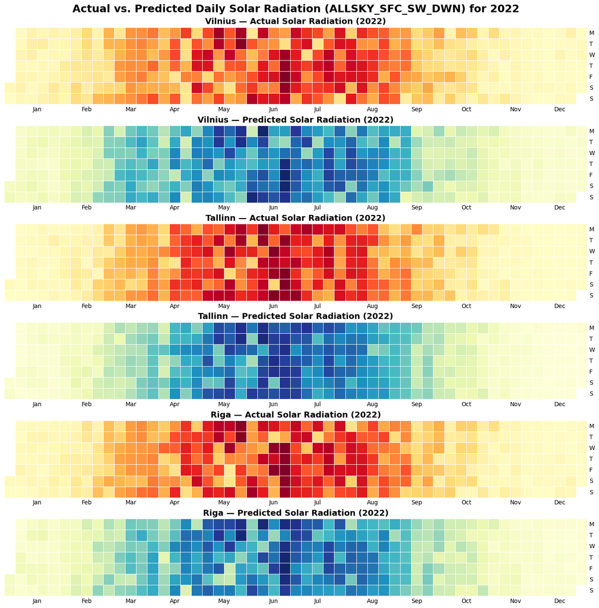

```python
# Actual 2022 series
act_v = y_test_df_Vilnius.rename('Actual')
act_t = y_test_df_Tallinn.rename('Actual')
act_r = y_test_df_Riga.rename('Actual')

cities = ['Vilnius', 'Tallinn', 'Riga']
actuals = {'Vilnius': act_v, 'Tallinn': act_t, 'Riga': act_r}
preds   = {'Vilnius': pred_v, 'Tallinn': pred_t, 'Riga': pred_r}

# --- Set up a 6‐row calendar‐heatmap (real above, predicted below) ---
fig, axes = plt.subplots(len(cities)*2, 1, figsize=(20, 14), constrained_layout=True)

for i, city in enumerate(cities):
    act = actuals[city]
    pr  = preds[city]
    # Use same color scale for direct comparison
    vmin, vmax = 0, max(act.max(), pr.max())

    # Real
    ax = axes[2*i]
    calmap.yearplot(
        act,
        year=2022,
        ax=ax,
        cmap='YlOrRd',
        fillcolor='lightgrey',
        linewidth=0.5,
        daylabels='MTWTFSS',
        dayticks=[0,1,2,3,4,5,6],
        vmin=vmin, vmax=vmax
    )
    ax.set_title(f'{city} — Actual Solar Radiation (2022)', fontsize=14, weight='bold')

    # Predicted
    ax = axes[2*i+1]
    calmap.yearplot(
        pr,
        year=2022,
        ax=ax,
        cmap='YlGnBu',
        fillcolor='lightgrey',
        linewidth=0.5,
        daylabels='MTWTFSS',
        dayticks=[0,1,2,3,4,5,6],
        vmin=vmin, vmax=vmax
    )
    ax.set_title(f'{city} — Predicted Solar Radiation (2022)', fontsize=14, weight='bold')

# Global title
fig.suptitle('Actual vs. Predicted Daily Solar Radiation (ALLSKY_SFC_SW_DWN) for 2022',
             fontsize=18, weight='bold', y=1.02)

plt.show()
```

### SHAP: Post-Hoc Explainability

To explain the output of our predictive model, we use SHAP (SHapley Additive exPlanations) values. SHAP allows us to quantify the contribution of each feature to an individual prediction, making the model's decisions more transparent. This approach helps both technical users and non-experts understand why the model made a specific prediction by revealing the underlying reasoning in a human-interpretable way.

Below, we implement the SHAP analysis based on the following steps:

- Step 1: load the dataset and Train the model (to fit SHAP input format)(we already have done this step)
- Step 2: Create and Instentate a SHAP explainer (KernelExplainer)
- Step 3: Bar chart of mean feature importance (Global Explanations of feature importance)
- Step 4: Visualize a single prediction(s) (Local Explanation)
- Step 5: Visualize many predictions (Local Overview) or Filtered predictions (Cohort)
- Step 6: Summary Plot

**Important Note:** In the scope of this project, SHAP analysis was performed only for the Vilnius dataset. Ideally, the same interpretability analysis should be applied to the other two cities (Tallinn and Riga) to ensure consistency and fairness in model evaluation. However, due to limited time and computational resources, we have skipped those for now.

**Step 1 & 2: load the dataset and Trained model, Create and Instentate a SHAP explainer (KernelExplainer)**

Code Explanation (SHAP with KernelExplainer):

- predict_fn:A simple function that takes a 2-D array or DataFrame and returns our stacking model’s predictions. SHAP’s KernelExplainer needs a pure function of X → y_pred.
- KernelExplainer: A model-agnostic method that estimates SHAP values by perturbing features and observing changes in predict_fn. It uses our background as a reference distribution.
- nsamples=100: Controls how many perturbed samples per explanation. Lower → faster, but noisier.
- X_small: A subset of 100 samples used for SHAP analysis to limit computational cost. This can be scaled up when more resources are available or needed for deeper insight.

```python
# We Pick a Trained Model and Data in this case Vilnius Dataset
X_train = X_train_df_Vilnius    # 2018–2021 training data
X_test  = X_test_df_Vilnius     # 2022 hold-out data

# 1) Define a thin wrapper so SHAP knows how to call our stacking model:
def predict_fn(X):
    # If X is a DataFrame, convert to the same column order that our model expects
    return stack_v.predict(pd.DataFrame(X, columns=X_train.columns))

# 2) Pick our background (reference) dataset # 100 background examples to speed things up(due to lack of computational resource)
background = X_train.sample(100, random_state=42)

# 3) Instantiate a KernelExplainer:
explainer = shap.KernelExplainer(predict_fn, background)

# 4) Compute SHAP values on a subset of our test set (it’s slow otherwise):
X_small = X_test.sample(100, random_state=0)
shap_values = explainer.shap_values(X_small, nsamples=100)
```

**Step 3: Bar chart of mean feature importance (Global Explanation):**  
This takes the average of the SHAP value magnitudes across the dataset and plots it as a simple bar chart

```
        feature  mean_abs_shap
5          RH2M       0.744674
15    DayOfYear       0.538164
3            TS       0.424666
6   PRECTOTCORR       0.237597
0           T2M       0.209413
16   WeekOfYear       0.113507
4          QV2M       0.093410
14         Year       0.083379
2        T2MWET       0.067128
8         WS10M       0.041293
```

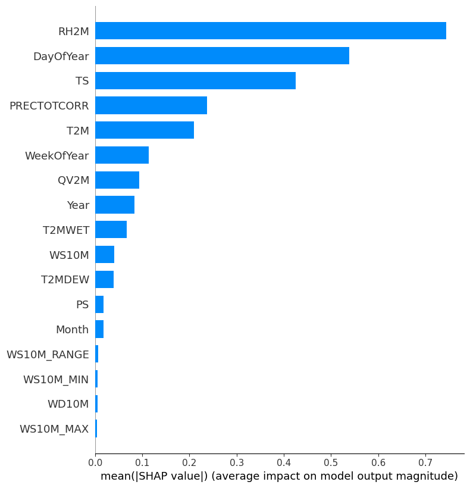

```python
# shap_values is a NumPy array of shape (n_samples, n_features)
mean_abs_shap = np.abs(shap_values).mean(axis=0)

fi = pd.DataFrame({
    'feature': X_small.columns,
    'mean_abs_shap': mean_abs_shap}).sort_values('mean_abs_shap', ascending=False)

print(fi.head(10))

shap.initjs()
shap.summary_plot(shap_values, X_small, plot_type="bar")
```

**Step 4: Visualize a single prediction (Local Explanation)**  
Waterfall plot

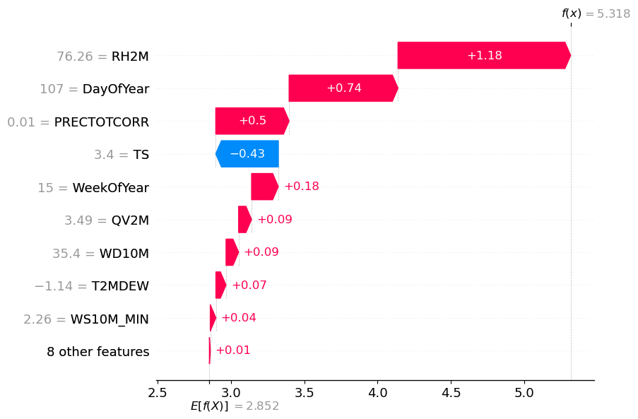

```python
# assume shap_values is our array of shape (N, M)
# and explainer.expected_value is a scalar (for our regression task)
i = 0  # index of the sample we want to explain
sample = X_small.iloc[i]                 # the i-th row of our DataFrame
sv = shap.Explanation(
    values = shap_values[i],               # SHAP values for that row
    base_values = explainer.expected_value,# the “null” prediction
    data = sample.values,                  # the feature vector
    feature_names = X_small.columns        # names for each feature
)
shap.plots.waterfall(sv)
```

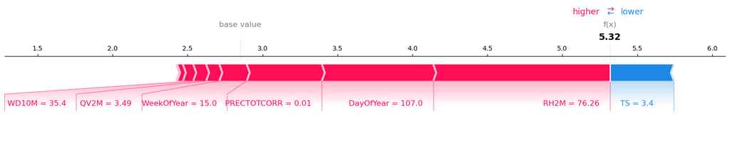

```python
# "String-like" plot
shap.initjs()
i=0
shap.force_plot(explainer.expected_value, shap_values[i,:], X_small.iloc[i,:], matplotlib=True )
```

**Step 5: Visualize many predictions (Local Overview) or Filtered predictions (Cohort)**  
Note: we only visualize data points for 100 individuals as we discussed earlier.

```python
# Visualize many predictions (Local Overview) or Filtered predictions (Cohort)
shap.initjs()
shap.force_plot(explainer.expected_value, shap_values[:100,:], X_small.iloc[:100,:])
```

**Step 6: SHAP Summary Plot**

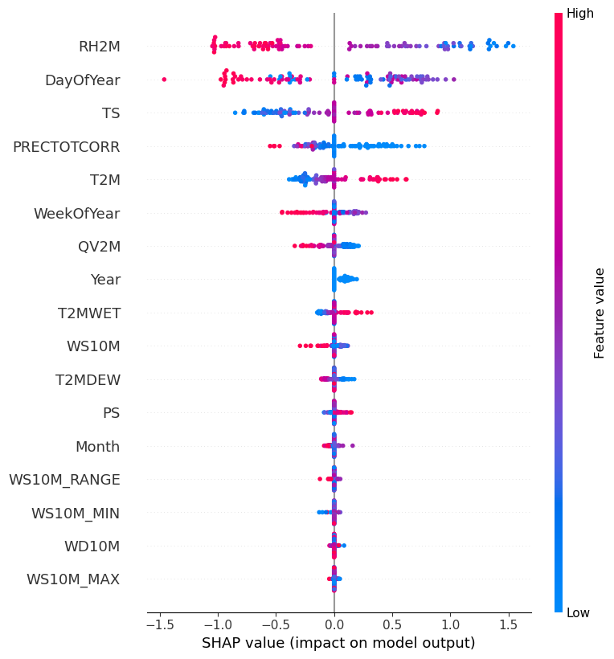

```python
# Make the summary plot:
shap.summary_plot(shap_values, X_small)
```

# 4.Prescriptive Analytics

### Turning Solar Forecasts into Actionable Decisions

With accurate day-ahead and intra-day solar irradiance predictions in hand, decision-makers can move from “what will happen” to “what should we do.” Based on the model's predictions of solar radiation, we can take action to improve energy efficiency and better prepare for future conditions. The model tells us how much solar energy is likely to be available on any given day, allowing energy planners to make smarter decisions. These include deciding when to charge batteries, when to use stored power, and when to reduce energy consumption during lower sunlight hours. By understanding what factors impact solar power—like humidity, temperature, or cloudiness—we can make better plans for clean energy use and reduce energy waste. Below are some prescriptions informed by our stacking model:

- **Maintenance & Cleaning Operations**
  - Panel Washing: Schedule panel cleaning on days with poor forecast (e.g. heavy cloudiness or precipitation) to minimize opportunity-cost of downtime. For instance, target days where predicted irradiance is below the 25th percentile.
  - Inspection Windows: Allocate maintenance crews on low-yield days (when SHAP shows humidity and precipitation strongly depress output) to maximize solar plant availability during peak-yield periods.

More technical actions to take:

- **Optimal PV Generation Scheduling**
  - Dispatch Battery Storage: When tomorrow’s forecasted irradiance exceeds a high threshold (e.g. > 5 kW·hr/m²), postpone discharging stored energy until late afternoon—maximizing self-consumption of abundant solar and avoiding grid peak charges. Conversely, on low-irradiance days (< 2 kW·hr/m²), pre-charge batteries during overnight off-peak hours to ensure reliable supply.
  - Curtailment & Grid Export: If local generation is forecast to exceed on-site load by > 20%, schedule controlled curtailment or negotiate feed-in tariffs in advance to avoid inverter clipping and lost revenue.
- **Demand-Side Management & Load Shifting**
  - Industrial Processes: For operations that can be time-shifted (e.g. water pumping, electrolysis), run energy-intensive tasks during high-irradiance windows identified by the model (e.g. DayOfYear 120–240), reducing reliance on grid power and cutting costs.
  - Residential Smart Charging: Integrate predictions into EV-charging schedules: ramp up home chargers or vehicle-to-grid discharge when forecast predicts surplus solar, and throttle back during low-solar hours.
- **Financial Hedging & Market Bidding**
  - Day-Ahead Market Offers: Use irradiance forecasts to fine-tune day-ahead generation bids, reducing imbalance penalties. For example, bid conservatively on days where high relative humidity signals cloudy conditions.
  - Option Strategies: Hedge against low-solar risk by purchasing call options on peak-demand hours when forecasts indicate under-production relative to baseline.

| What If? | Consequences | Likelihood | Severity | Recommendations |
| --- | --- | --- | --- | --- |
| Humidity spikes for a full week | Less solar energy is produced. Daily output drops. | Medium | Moderate | Use stored power wisely. Schedule high-energy tasks earlier in the day. |
| Several clear sunny days in a row | High solar energy generation, more than average. | High | Low | Charge storage systems fully. Run energy-heavy tasks during peak sun hours. |
| Unusual afternoon cloud coverage | Sudden drop in energy during the afternoon peak. | High | High | Shift key activities to mornings. Use backup power sources to meet energy needs. |

More technical 'What-if' scenarios:

[output not shown]

# How the model will be used in real life:

In a real-world setting, this stacking-ensemble solar-radiation model would sit at the heart of an automated daily forecasting pipeline that drives decision-making across generation, operations and planning:

- **Data Ingestion & Preprocessing**  
  • Every morning (or more frequently), the meteorological data feed (the same 19 GHI/temperature/humidity/wind parameters) is automatically pulled and time-indexed.  
  • A small ETL job applies exactly the same feature-engineering steps we used in development (dropping leakage features, computing Year/DayOfYear/WeekOfYear, scaling for SVR/MLP pipelines, etc.).
- **Prediction Service**  
  • A lightweight API (e.g. Flask/FastAPI or an enterprise scheduler) loads the latest cleaned features and calls our pre-trained stacking model for Vilnius, Tallinn and Riga.  
  • It writes out a day-ahead forecast of ALLSKY_SFC_SW_DWN for each location—for example as a simple CSV, database table, or JSON payload.
- **Integration with Operations**  
  • PV Plant Scheduling: Operators use the forecast to size inverter output, schedule panel cleaning/maintenance on low-irradiance days, and optimize battery charge/discharge cycles.  
  • Grid Balancing & Market Bids: Utilities and traders feed the day-ahead solar forecasts into their unit-commitment models to decide how much conventional generation to keep spinning and what appetite to bid into spot markets.  
  • Demand Response & Storage Management: Energy managers adjust flexible loads (e.g. EV charging, HVAC pre-cooling) when high‐radiation days are expected, maximizing consumption of clean solar.
- **Visualization & Alerts** • A daily dashboard shows side-by-side heat-maps (actual vs. predicted) and key error metrics.  
  • Automated alerts (e.g. via Slack or SMS) flag any unusually low or high forecasts—so teams can investigate sensor outages or extreme weather risks.
- **Feedback & Retraining**  
  • At the end of each month/quarter, the actual 2022 (and beyond) observations are compared against our forecasts to track model drift.  
  • we schedule a quarterly retraining job that incorporates the newest data into our stack, re-optimizes hyperparameters (if needed), and refreshes the production model.
- **Governance & Continuous Improvement**  
  • we log predictions, actuals and feature distributions to monitor data quality, model stability and bias (e.g. does it under‐predict in winter?).  
  • If performance dips below a threshold (say RMSE > 1 kW-hr/m²), a notification triggers a deeper error‐analysis process or even an automated rollback to the last known-good model.

By embedding this model into a repeatable, monitored forecasting pipeline—complete with automated data ingestion, model serving, dashboarding and retraining— we turn our proof-of-concept into a robust, production-grade decision-support system that helps PV operators, grid planners and energy traders make cleaner, more efficient, data-driven choices every single day.